# Предсказание ухода клиентов для оператора связи «ТелеДом»

Оператор связи «ТелеДом» поланирует бороться с оттоком клиентов путем предоставления промокодов и специальных условий всем, кто планирует отказаться от услуг связи, чтобы заранее находить таких пользователей, «ТелеДому» нужна модель, которая будет предсказывать, разорвёт ли абонент договор.

**Задача:** настроить модель машинного обучения для прогноза оттока клиентов с показателем качества AUC-ROC не ниже 0.85.

Планируется обучить следующие модели:

- Древовидные модели - дерева решений и случайного леса,
- Модель логистической регрессии,
- Модели бустинга - LightGBM и CatBoost.

Для обучения модели заказчик предоставил персональные данные о некоторых клиентах, информацию об их тарифах и услугах.

**План работы:**

1. Загрузка данных
2. Предобработка данных
3. Объединение данных
4. Исследовательский анализ и предобработка данных объединённого датафрейма
5. Подготовка данных
6. Обучение моделей машинного обучения
7. Выбор лучшей модели
8. Общий вывод и рекомендации заказчику

## Загрузка данных

```python
import pandas as pd
import numpy as np
import matplotlib.pyplot as plt
import phik
import lightgbm as lgb
import seaborn as sns

from phik.report import plot_correlation_matrix
from phik import report

from sklearn.tree import DecisionTreeClassifier
from sklearn.ensemble import RandomForestClassifier
from sklearn.linear_model import LogisticRegression
from lightgbm import LGBMClassifier

from sklearn.metrics import roc_auc_score, accuracy_score, roc_curve, confusion_matrix
from sklearn.model_selection import GridSearchCV, train_test_split

from sklearn.pipeline import make_pipeline
from sklearn.preprocessing import OrdinalEncoder, StandardScaler, MinMaxScaler

from catboost import CatBoostClassifier

import warnings
warnings.filterwarnings("ignore")

RANDOM_STATE = 150324
```

```python
# загрузка данных

contract_data = pd.read_csv('contract_new.csv')
personal_data = pd.read_csv('personal_new.csv')
internet_data = pd.read_csv('internet_new.csv')
phone_data = pd.read_csv('phone_new.csv')
```

```python
# обзор данных о договорах

display(contract_data.head())
display('Количество дубликатов:', contract_data.duplicated().sum())
display(contract_data.info())
```

|  | customerID | BeginDate | EndDate | Type | PaperlessBilling | PaymentMethod | MonthlyCharges | TotalCharges |
| --- | --- | --- | --- | --- | --- | --- | --- | --- |
| 0 | 7590-VHVEG | 2020-01-01 | No | Month-to-month | Yes | Electronic check | 29.85 | 31.04 |
| 1 | 5575-GNVDE | 2017-04-01 | No | One year | No | Mailed check | 56.95 | 2071.84 |
| 2 | 3668-QPYBK | 2019-10-01 | No | Month-to-month | Yes | Mailed check | 53.85 | 226.17 |
| 3 | 7795-CFOCW | 2016-05-01 | No | One year | No | Bank transfer (automatic) | 42.30 | 1960.6 |
| 4 | 9237-HQITU | 2019-09-01 | No | Month-to-month | Yes | Electronic check | 70.70 | 353.5 |

```
'Количество дубликатов:'
```

```
0
```

```
<class 'pandas.core.frame.DataFrame'>
RangeIndex: 7043 entries, 0 to 7042
Data columns (total 8 columns):
 #   Column            Non-Null Count  Dtype
---  ------            --------------  -----
 0   customerID        7043 non-null   object
 1   BeginDate         7043 non-null   object
 2   EndDate           7043 non-null   object
 3   Type              7043 non-null   object
 4   PaperlessBilling  7043 non-null   object
 5   PaymentMethod     7043 non-null   object
 6   MonthlyCharges    7043 non-null   float64
 7   TotalCharges      7043 non-null   object
dtypes: float64(1), object(7)
memory usage: 440.3+ KB
```

```
None
```

Обзор файла с информацией о договоре показал, что данные соответствуют описанию, не содержат дубликатов и пропусков, при этом тип данных не соответствует содержанию в столбцах BeginDate, EndDate и TotalCharges - это будет изменено на этапе предобработки данных.

```python
# обзор данных о клиентах

display(personal_data.head())
display('Количество дубликатов:', personal_data.duplicated().sum())
display(personal_data.info())
```

|  | customerID | gender | SeniorCitizen | Partner | Dependents |
| --- | --- | --- | --- | --- | --- |
| 0 | 7590-VHVEG | Female | 0 | Yes | No |
| 1 | 5575-GNVDE | Male | 0 | No | No |
| 2 | 3668-QPYBK | Male | 0 | No | No |
| 3 | 7795-CFOCW | Male | 0 | No | No |
| 4 | 9237-HQITU | Female | 0 | No | No |

```
'Количество дубликатов:'
```

```
0
```

```
<class 'pandas.core.frame.DataFrame'>
RangeIndex: 7043 entries, 0 to 7042
Data columns (total 5 columns):
 #   Column         Non-Null Count  Dtype
---  ------         --------------  -----
 0   customerID     7043 non-null   object
 1   gender         7043 non-null   object
 2   SeniorCitizen  7043 non-null   int64
 3   Partner        7043 non-null   object
 4   Dependents     7043 non-null   object
dtypes: int64(1), object(4)
memory usage: 275.2+ KB
```

```
None
```

Данные о клиентах соответствуют описанию, не содержат дубликатов и пропусков, тип данных корректный.

```python
display('Уникальные данные:', internet_data['InternetService'].unique())
```

```
'Уникальные данные:'
```

```
array(['DSL', 'Fiber optic'], dtype=object)
```

```python
# обзор данных об интернет-услугах

display(internet_data.head())
display('Количество дубликатов:', internet_data.duplicated().sum())
display(internet_data.info())
```

|  | customerID | InternetService | OnlineSecurity | OnlineBackup | DeviceProtection | TechSupport | StreamingTV | StreamingMovies |
| --- | --- | --- | --- | --- | --- | --- | --- | --- |
| 0 | 7590-VHVEG | DSL | No | Yes | No | No | No | No |
| 1 | 5575-GNVDE | DSL | Yes | No | Yes | No | No | No |
| 2 | 3668-QPYBK | DSL | Yes | Yes | No | No | No | No |
| 3 | 7795-CFOCW | DSL | Yes | No | Yes | Yes | No | No |
| 4 | 9237-HQITU | Fiber optic | No | No | No | No | No | No |

```
'Количество дубликатов:'
```

```
0
```

```
<class 'pandas.core.frame.DataFrame'>
RangeIndex: 5517 entries, 0 to 5516
Data columns (total 8 columns):
 #   Column            Non-Null Count  Dtype
---  ------            --------------  -----
 0   customerID        5517 non-null   object
 1   InternetService   5517 non-null   object
 2   OnlineSecurity    5517 non-null   object
 3   OnlineBackup      5517 non-null   object
 4   DeviceProtection  5517 non-null   object
 5   TechSupport       5517 non-null   object
 6   StreamingTV       5517 non-null   object
 7   StreamingMovies   5517 non-null   object
dtypes: object(8)
memory usage: 344.9+ KB
```

```
None
```

Данные об интернет-услугах соответствуют описанию, не содержат дубликатов и пропусков, тип данных корректный. При этом количество записей меньше, чем записей о клиентах и договорах, что может говорить о том, что не все клиенты пользуются интернет-услугами.

```python
# обзор данных об услугах телефонии

display(phone_data.head())
display('Количество дубликатов:', phone_data.duplicated().sum())
display(phone_data.info())
```

|  | customerID | MultipleLines |
| --- | --- | --- |
| 0 | 5575-GNVDE | No |
| 1 | 3668-QPYBK | No |
| 2 | 9237-HQITU | No |
| 3 | 9305-CDSKC | Yes |
| 4 | 1452-KIOVK | Yes |

```
'Количество дубликатов:'
```

```
0
```

```
<class 'pandas.core.frame.DataFrame'>
RangeIndex: 6361 entries, 0 to 6360
Data columns (total 2 columns):
 #   Column         Non-Null Count  Dtype
---  ------         --------------  -----
 0   customerID     6361 non-null   object
 1   MultipleLines  6361 non-null   object
dtypes: object(2)
memory usage: 99.5+ KB
```

```
None
```

Данные об услугах телефонии соответствуют описанию, не содержат дубликатов и пропусков, тип данных корректный. При этом количество записей меньше, чем записей о клиентах и договорах, что может говорить о том, что не все клиенты пользуются услугами телефонии.

### Промежуточный вывод

Первичных обзор данных показал следующее:

1. Данные в файле с информацией о договоре соответствуют описанию, не содержат дубликатов и пропусков, при этом тип данных не соответствует содержанию в столбцах BeginDate, EndDate и TotalCharges - это будет изменено на этапе предобработки данных.
2. Данные о клиентах соответствуют описанию, не содержат дубликатов и пропусков, тип данных корректный.
3. Данные об интернет-услугах соответствуют описанию, не содержат дубликатов и пропусков, тип данных корректный. При этом количество записей меньше, чем записей о клиентах и договорах, что может говорить о том, что не все клиенты пользуются интернет-услугами.
4. Данные об услугах телефонии соответствуют описанию, не содержат дубликатов и пропусков, тип данных корректный. При этом количество записей также меньше, что может говорить о том, что не все клиенты пользуются услугами телефонии.

## Предобработка данных

```python
# обзор датасета с данными

contract_data.head()
```

|  | customerID | BeginDate | EndDate | Type | PaperlessBilling | PaymentMethod | MonthlyCharges | TotalCharges |
| --- | --- | --- | --- | --- | --- | --- | --- | --- |
| 0 | 7590-VHVEG | 2020-01-01 | No | Month-to-month | Yes | Electronic check | 29.85 | 31.04 |
| 1 | 5575-GNVDE | 2017-04-01 | No | One year | No | Mailed check | 56.95 | 2071.84 |
| 2 | 3668-QPYBK | 2019-10-01 | No | Month-to-month | Yes | Mailed check | 53.85 | 226.17 |
| 3 | 7795-CFOCW | 2016-05-01 | No | One year | No | Bank transfer (automatic) | 42.30 | 1960.6 |
| 4 | 9237-HQITU | 2019-09-01 | No | Month-to-month | Yes | Electronic check | 70.70 | 353.5 |

```python
# проверка уникальных данных в столбце с датой окончания договора

display('Уникальные данные:', contract_data['EndDate'].unique())
```

```
'Уникальные данные:'
```

```
array(['No', '2017-05-01', '2016-03-01', '2018-09-01', '2018-11-01',
       '2018-12-01', '2019-08-01', '2018-07-01', '2017-09-01',
       '2015-09-01', '2016-07-01', '2016-06-01', '2018-03-01',
       '2019-02-01', '2018-06-01', '2019-06-01', '2020-01-01',
       '2019-11-01', '2016-09-01', '2015-06-01', '2016-12-01',
       '2019-05-01', '2019-04-01', '2017-06-01', '2017-08-01',
       '2018-04-01', '2018-08-01', '2018-02-01', '2019-07-01',
       '2015-12-01', '2014-06-01', '2018-10-01', '2019-01-01',
       '2017-07-01', '2017-12-01', '2018-05-01', '2015-11-01',
       '2019-10-01', '2019-03-01', '2016-02-01', '2016-10-01',
       '2018-01-01', '2017-11-01', '2015-10-01', '2019-12-01',
       '2015-07-01', '2017-04-01', '2015-02-01', '2017-03-01',
       '2016-05-01', '2016-11-01', '2015-08-01', '2019-09-01',
       '2017-10-01', '2017-02-01', '2016-08-01', '2016-04-01',
       '2015-05-01', '2014-09-01', '2014-10-01', '2017-01-01',
       '2015-03-01', '2015-01-01', '2016-01-01', '2015-04-01',
       '2014-12-01', '2014-11-01'], dtype=object)
```

```python
# замена текста No в столбце EndDate на "заглушку" - дату отчета

contract_data.loc[contract_data['EndDate'] == 'No', 'EndDate'] = '2020-02-01'
display('Уникальные данные:', contract_data['EndDate'].unique())
```

```
'Уникальные данные:'
```

```
array(['2020-02-01', '2017-05-01', '2016-03-01', '2018-09-01',
       '2018-11-01', '2018-12-01', '2019-08-01', '2018-07-01',
       '2017-09-01', '2015-09-01', '2016-07-01', '2016-06-01',
       '2018-03-01', '2019-02-01', '2018-06-01', '2019-06-01',
       '2020-01-01', '2019-11-01', '2016-09-01', '2015-06-01',
       '2016-12-01', '2019-05-01', '2019-04-01', '2017-06-01',
       '2017-08-01', '2018-04-01', '2018-08-01', '2018-02-01',
       '2019-07-01', '2015-12-01', '2014-06-01', '2018-10-01',
       '2019-01-01', '2017-07-01', '2017-12-01', '2018-05-01',
       '2015-11-01', '2019-10-01', '2019-03-01', '2016-02-01',
       '2016-10-01', '2018-01-01', '2017-11-01', '2015-10-01',
       '2019-12-01', '2015-07-01', '2017-04-01', '2015-02-01',
       '2017-03-01', '2016-05-01', '2016-11-01', '2015-08-01',
       '2019-09-01', '2017-10-01', '2017-02-01', '2016-08-01',
       '2016-04-01', '2015-05-01', '2014-09-01', '2014-10-01',
       '2017-01-01', '2015-03-01', '2015-01-01', '2016-01-01',
       '2015-04-01', '2014-12-01', '2014-11-01'], dtype=object)
```

```python
# изменение типов данных в столбцах с датой

contract_data['BeginDate'] = pd.to_datetime(contract_data['BeginDate'], format = '%Y-%m-%d')
contract_data['EndDate'] = pd.to_datetime(contract_data['EndDate'], format = '%Y-%m-%d')

contract_data.info()
```

```
<class 'pandas.core.frame.DataFrame'>
RangeIndex: 7043 entries, 0 to 7042
Data columns (total 8 columns):
 #   Column            Non-Null Count  Dtype
---  ------            --------------  -----
 0   customerID        7043 non-null   object
 1   BeginDate         7043 non-null   datetime64[ns]
 2   EndDate           7043 non-null   datetime64[ns]
 3   Type              7043 non-null   object
 4   PaperlessBilling  7043 non-null   object
 5   PaymentMethod     7043 non-null   object
 6   MonthlyCharges    7043 non-null   float64
 7   TotalCharges      7043 non-null   object
dtypes: datetime64[ns](2), float64(1), object(5)
memory usage: 440.3+ KB
```

```python
# заменяем пропуском символ " ", из-за которого возвращалась ошибка при изменении типа данных в столбце TotalCharges

contract_data['TotalCharges'] = contract_data['TotalCharges'].replace(' ', np.nan)

contract_data['TotalCharges'] = contract_data['TotalCharges'].astype(float)

contract_data.info()
```

```
<class 'pandas.core.frame.DataFrame'>
RangeIndex: 7043 entries, 0 to 7042
Data columns (total 8 columns):
 #   Column            Non-Null Count  Dtype
---  ------            --------------  -----
 0   customerID        7043 non-null   object
 1   BeginDate         7043 non-null   datetime64[ns]
 2   EndDate           7043 non-null   datetime64[ns]
 3   Type              7043 non-null   object
 4   PaperlessBilling  7043 non-null   object
 5   PaymentMethod     7043 non-null   object
 6   MonthlyCharges    7043 non-null   float64
 7   TotalCharges      7032 non-null   float64
dtypes: datetime64[ns](2), float64(2), object(4)
memory usage: 440.3+ KB
```

```python
# проверка пропусков в TotalCharges

contract_data.loc[contract_data['TotalCharges'].isnull()]
```

|  | customerID | BeginDate | EndDate | Type | PaperlessBilling | PaymentMethod | MonthlyCharges | TotalCharges |
| --- | --- | --- | --- | --- | --- | --- | --- | --- |
| 488 | 4472-LVYGI | 2020-02-01 | 2020-02-01 | Two year | Yes | Bank transfer (automatic) | 52.55 | NaN |
| 753 | 3115-CZMZD | 2020-02-01 | 2020-02-01 | Two year | No | Mailed check | 20.25 | NaN |
| 936 | 5709-LVOEQ | 2020-02-01 | 2020-02-01 | Two year | No | Mailed check | 80.85 | NaN |
| 1082 | 4367-NUYAO | 2020-02-01 | 2020-02-01 | Two year | No | Mailed check | 25.75 | NaN |
| 1340 | 1371-DWPAZ | 2020-02-01 | 2020-02-01 | Two year | No | Credit card (automatic) | 56.05 | NaN |
| 3331 | 7644-OMVMY | 2020-02-01 | 2020-02-01 | Two year | No | Mailed check | 19.85 | NaN |
| 3826 | 3213-VVOLG | 2020-02-01 | 2020-02-01 | Two year | No | Mailed check | 25.35 | NaN |
| 4380 | 2520-SGTTA | 2020-02-01 | 2020-02-01 | Two year | No | Mailed check | 20.00 | NaN |
| 5218 | 2923-ARZLG | 2020-02-01 | 2020-02-01 | One year | Yes | Mailed check | 19.70 | NaN |
| 6670 | 4075-WKNIU | 2020-02-01 | 2020-02-01 | Two year | No | Mailed check | 73.35 | NaN |
| 6754 | 2775-SEFEE | 2020-02-01 | 2020-02-01 | Two year | Yes | Bank transfer (automatic) | 61.90 | NaN |

Пропуски в столбце TotalCharges соответствую договорам, дата начала которых равна дате, на котовую выгружены данные - 01.02.2020, т.е. у данных клиентов к указанной дате ещё не возникло начислений - т.о. корректно будет заполнить пропуски нулевым значением.

```python
# замена пропусков на 0

contract_data['TotalCharges'] = contract_data['TotalCharges'].fillna(value = 0)

contract_data.info()
```

```
<class 'pandas.core.frame.DataFrame'>
RangeIndex: 7043 entries, 0 to 7042
Data columns (total 8 columns):
 #   Column            Non-Null Count  Dtype
---  ------            --------------  -----
 0   customerID        7043 non-null   object
 1   BeginDate         7043 non-null   datetime64[ns]
 2   EndDate           7043 non-null   datetime64[ns]
 3   Type              7043 non-null   object
 4   PaperlessBilling  7043 non-null   object
 5   PaymentMethod     7043 non-null   object
 6   MonthlyCharges    7043 non-null   float64
 7   TotalCharges      7043 non-null   float64
dtypes: datetime64[ns](2), float64(2), object(4)
memory usage: 440.3+ KB
```

## Объединение данных

```python
# присоединяем персональные данные клиентов к датасету с договорами

data = contract_data.merge(personal_data, on='customerID')
display(data.info())
data.head()
```

```
<class 'pandas.core.frame.DataFrame'>
RangeIndex: 7043 entries, 0 to 7042
Data columns (total 12 columns):
 #   Column            Non-Null Count  Dtype
---  ------            --------------  -----
 0   customerID        7043 non-null   object
 1   BeginDate         7043 non-null   datetime64[ns]
 2   EndDate           7043 non-null   datetime64[ns]
 3   Type              7043 non-null   object
 4   PaperlessBilling  7043 non-null   object
 5   PaymentMethod     7043 non-null   object
 6   MonthlyCharges    7043 non-null   float64
 7   TotalCharges      7043 non-null   float64
 8   gender            7043 non-null   object
 9   SeniorCitizen     7043 non-null   int64
 10  Partner           7043 non-null   object
 11  Dependents        7043 non-null   object
dtypes: datetime64[ns](2), float64(2), int64(1), object(7)
memory usage: 660.4+ KB
```

```
None
```

|  | customerID | BeginDate | EndDate | Type | PaperlessBilling | PaymentMethod | MonthlyCharges | TotalCharges | gender | SeniorCitizen | Partner | Dependents |
| --- | --- | --- | --- | --- | --- | --- | --- | --- | --- | --- | --- | --- |
| 0 | 7590-VHVEG | 2020-01-01 | 2020-02-01 | Month-to-month | Yes | Electronic check | 29.85 | 31.04 | Female | 0 | Yes | No |
| 1 | 5575-GNVDE | 2017-04-01 | 2020-02-01 | One year | No | Mailed check | 56.95 | 2071.84 | Male | 0 | No | No |
| 2 | 3668-QPYBK | 2019-10-01 | 2020-02-01 | Month-to-month | Yes | Mailed check | 53.85 | 226.17 | Male | 0 | No | No |
| 3 | 7795-CFOCW | 2016-05-01 | 2020-02-01 | One year | No | Bank transfer (automatic) | 42.30 | 1960.60 | Male | 0 | No | No |
| 4 | 9237-HQITU | 2019-09-01 | 2020-02-01 | Month-to-month | Yes | Electronic check | 70.70 | 353.50 | Female | 0 | No | No |

```python
# присоединяем данные об интернет-услугах к новому датасету

data = data.merge(internet_data, on='customerID', how='left')
display(data.info())
data.head()
```

```
<class 'pandas.core.frame.DataFrame'>
RangeIndex: 7043 entries, 0 to 7042
Data columns (total 19 columns):
 #   Column            Non-Null Count  Dtype
---  ------            --------------  -----
 0   customerID        7043 non-null   object
 1   BeginDate         7043 non-null   datetime64[ns]
 2   EndDate           7043 non-null   datetime64[ns]
 3   Type              7043 non-null   object
 4   PaperlessBilling  7043 non-null   object
 5   PaymentMethod     7043 non-null   object
 6   MonthlyCharges    7043 non-null   float64
 7   TotalCharges      7043 non-null   float64
 8   gender            7043 non-null   object
 9   SeniorCitizen     7043 non-null   int64
 10  Partner           7043 non-null   object
 11  Dependents        7043 non-null   object
 12  InternetService   5517 non-null   object
 13  OnlineSecurity    5517 non-null   object
 14  OnlineBackup      5517 non-null   object
 15  DeviceProtection  5517 non-null   object
 16  TechSupport       5517 non-null   object
 17  StreamingTV       5517 non-null   object
 18  StreamingMovies   5517 non-null   object
dtypes: datetime64[ns](2), float64(2), int64(1), object(14)
memory usage: 1.0+ MB
```

```
None
```

|  | customerID | BeginDate | EndDate | Type | PaperlessBilling | PaymentMethod | MonthlyCharges | TotalCharges | gender | SeniorCitizen | Partner | Dependents | InternetService | OnlineSecurity | OnlineBackup | DeviceProtection | TechSupport | StreamingTV | StreamingMovies |
| --- | --- | --- | --- | --- | --- | --- | --- | --- | --- | --- | --- | --- | --- | --- | --- | --- | --- | --- | --- |
| 0 | 7590-VHVEG | 2020-01-01 | 2020-02-01 | Month-to-month | Yes | Electronic check | 29.85 | 31.04 | Female | 0 | Yes | No | DSL | No | Yes | No | No | No | No |
| 1 | 5575-GNVDE | 2017-04-01 | 2020-02-01 | One year | No | Mailed check | 56.95 | 2071.84 | Male | 0 | No | No | DSL | Yes | No | Yes | No | No | No |
| 2 | 3668-QPYBK | 2019-10-01 | 2020-02-01 | Month-to-month | Yes | Mailed check | 53.85 | 226.17 | Male | 0 | No | No | DSL | Yes | Yes | No | No | No | No |
| 3 | 7795-CFOCW | 2016-05-01 | 2020-02-01 | One year | No | Bank transfer (automatic) | 42.30 | 1960.60 | Male | 0 | No | No | DSL | Yes | No | Yes | Yes | No | No |
| 4 | 9237-HQITU | 2019-09-01 | 2020-02-01 | Month-to-month | Yes | Electronic check | 70.70 | 353.50 | Female | 0 | No | No | Fiber optic | No | No | No | No | No | No |

```python
# присоединяем данные об услугах телефонии к новому датасету

data = data.merge(phone_data, on='customerID', how='left')
data.head()
```

|  | customerID | BeginDate | EndDate | Type | PaperlessBilling | PaymentMethod | MonthlyCharges | TotalCharges | gender | SeniorCitizen | Partner | Dependents | InternetService | OnlineSecurity | OnlineBackup | DeviceProtection | TechSupport | StreamingTV | StreamingMovies | MultipleLines |
| --- | --- | --- | --- | --- | --- | --- | --- | --- | --- | --- | --- | --- | --- | --- | --- | --- | --- | --- | --- | --- |
| 0 | 7590-VHVEG | 2020-01-01 | 2020-02-01 | Month-to-month | Yes | Electronic check | 29.85 | 31.04 | Female | 0 | Yes | No | DSL | No | Yes | No | No | No | No | NaN |
| 1 | 5575-GNVDE | 2017-04-01 | 2020-02-01 | One year | No | Mailed check | 56.95 | 2071.84 | Male | 0 | No | No | DSL | Yes | No | Yes | No | No | No | No |
| 2 | 3668-QPYBK | 2019-10-01 | 2020-02-01 | Month-to-month | Yes | Mailed check | 53.85 | 226.17 | Male | 0 | No | No | DSL | Yes | Yes | No | No | No | No | No |
| 3 | 7795-CFOCW | 2016-05-01 | 2020-02-01 | One year | No | Bank transfer (automatic) | 42.30 | 1960.60 | Male | 0 | No | No | DSL | Yes | No | Yes | Yes | No | No | NaN |
| 4 | 9237-HQITU | 2019-09-01 | 2020-02-01 | Month-to-month | Yes | Electronic check | 70.70 | 353.50 | Female | 0 | No | No | Fiber optic | No | No | No | No | No | No | No |

```python
# обзор полученных данных

data.info()
```

```
<class 'pandas.core.frame.DataFrame'>
RangeIndex: 7043 entries, 0 to 7042
Data columns (total 20 columns):
 #   Column            Non-Null Count  Dtype
---  ------            --------------  -----
 0   customerID        7043 non-null   object
 1   BeginDate         7043 non-null   datetime64[ns]
 2   EndDate           7043 non-null   datetime64[ns]
 3   Type              7043 non-null   object
 4   PaperlessBilling  7043 non-null   object
 5   PaymentMethod     7043 non-null   object
 6   MonthlyCharges    7043 non-null   float64
 7   TotalCharges      7043 non-null   float64
 8   gender            7043 non-null   object
 9   SeniorCitizen     7043 non-null   int64
 10  Partner           7043 non-null   object
 11  Dependents        7043 non-null   object
 12  InternetService   5517 non-null   object
 13  OnlineSecurity    5517 non-null   object
 14  OnlineBackup      5517 non-null   object
 15  DeviceProtection  5517 non-null   object
 16  TechSupport       5517 non-null   object
 17  StreamingTV       5517 non-null   object
 18  StreamingMovies   5517 non-null   object
 19  MultipleLines     6361 non-null   object
dtypes: datetime64[ns](2), float64(2), int64(1), object(15)
memory usage: 1.1+ MB
```

В объединенном датасете появились пропуски, связанные с тем, что не все клиенты используют интернет-услуги и услуги телефонии, поэтому заполним пропуски значением No.

```python
# заполнение пропусков

data['InternetService'] = data['InternetService'].fillna(value = 'No')
data['OnlineSecurity'] = data['OnlineSecurity'].fillna(value = 'No')
data['OnlineBackup'] = data['OnlineBackup'].fillna(value = 'No')
data['DeviceProtection'] = data['DeviceProtection'].fillna(value = 'No')
data['TechSupport'] = data['TechSupport'].fillna(value = 'No')
data['StreamingTV'] = data['StreamingTV'].fillna(value = 'No')
data['StreamingMovies'] = data['StreamingMovies'].fillna(value = 'No')
data['MultipleLines'] = data['MultipleLines'].fillna(value = 'No')

data.info()
```

```
<class 'pandas.core.frame.DataFrame'>
RangeIndex: 7043 entries, 0 to 7042
Data columns (total 20 columns):
 #   Column            Non-Null Count  Dtype
---  ------            --------------  -----
 0   customerID        7043 non-null   object
 1   BeginDate         7043 non-null   datetime64[ns]
 2   EndDate           7043 non-null   datetime64[ns]
 3   Type              7043 non-null   object
 4   PaperlessBilling  7043 non-null   object
 5   PaymentMethod     7043 non-null   object
 6   MonthlyCharges    7043 non-null   float64
 7   TotalCharges      7043 non-null   float64
 8   gender            7043 non-null   object
 9   SeniorCitizen     7043 non-null   int64
 10  Partner           7043 non-null   object
 11  Dependents        7043 non-null   object
 12  InternetService   7043 non-null   object
 13  OnlineSecurity    7043 non-null   object
 14  OnlineBackup      7043 non-null   object
 15  DeviceProtection  7043 non-null   object
 16  TechSupport       7043 non-null   object
 17  StreamingTV       7043 non-null   object
 18  StreamingMovies   7043 non-null   object
 19  MultipleLines     7043 non-null   object
dtypes: datetime64[ns](2), float64(2), int64(1), object(15)
memory usage: 1.1+ MB
```

```python
# проверка на дубликаты

('Количество дубликатов:', phone_data.duplicated().sum())
data.head()
```

|  | customerID | BeginDate | EndDate | Type | PaperlessBilling | PaymentMethod | MonthlyCharges | TotalCharges | gender | SeniorCitizen | Partner | Dependents | InternetService | OnlineSecurity | OnlineBackup | DeviceProtection | TechSupport | StreamingTV | StreamingMovies | MultipleLines |
| --- | --- | --- | --- | --- | --- | --- | --- | --- | --- | --- | --- | --- | --- | --- | --- | --- | --- | --- | --- | --- |
| 0 | 7590-VHVEG | 2020-01-01 | 2020-02-01 | Month-to-month | Yes | Electronic check | 29.85 | 31.04 | Female | 0 | Yes | No | DSL | No | Yes | No | No | No | No | No |
| 1 | 5575-GNVDE | 2017-04-01 | 2020-02-01 | One year | No | Mailed check | 56.95 | 2071.84 | Male | 0 | No | No | DSL | Yes | No | Yes | No | No | No | No |
| 2 | 3668-QPYBK | 2019-10-01 | 2020-02-01 | Month-to-month | Yes | Mailed check | 53.85 | 226.17 | Male | 0 | No | No | DSL | Yes | Yes | No | No | No | No | No |
| 3 | 7795-CFOCW | 2016-05-01 | 2020-02-01 | One year | No | Bank transfer (automatic) | 42.30 | 1960.60 | Male | 0 | No | No | DSL | Yes | No | Yes | Yes | No | No | No |
| 4 | 9237-HQITU | 2019-09-01 | 2020-02-01 | Month-to-month | Yes | Electronic check | 70.70 | 353.50 | Female | 0 | No | No | Fiber optic | No | No | No | No | No | No | No |

### Промежуточный вывод

В рамках данного шага проведено присоединение таблиц с персональными данными и информации об интернет-услугах и телефонии к основной таблице с информацией о договорах.

В объединенном датасете появились пропуски, связанные с тем, что не все клиенты используют интернет-услуги и услуги телефонии, поэтому пропуски были заполнены значением No.

## Исследовательский анализ и предобработка данных объединённого датафрейма

### Предобработка данных

```python
# создание объединенного признака для дат начала и окончания договоров

data['CombDates'] = data['BeginDate'].astype('str') + '_' + data['EndDate'].astype('str')

data.head()
```

|  | customerID | BeginDate | EndDate | Type | PaperlessBilling | PaymentMethod | MonthlyCharges | TotalCharges | gender | SeniorCitizen | ... | Dependents | InternetService | OnlineSecurity | OnlineBackup | DeviceProtection | TechSupport | StreamingTV | StreamingMovies | MultipleLines | CombDates |
| --- | --- | --- | --- | --- | --- | --- | --- | --- | --- | --- | --- | --- | --- | --- | --- | --- | --- | --- | --- | --- | --- |
| 0 | 7590-VHVEG | 2020-01-01 | 2020-02-01 | Month-to-month | Yes | Electronic check | 29.85 | 31.04 | Female | 0 | ... | No | DSL | No | Yes | No | No | No | No | No | 2020-01-01_2020-02-01 |
| 1 | 5575-GNVDE | 2017-04-01 | 2020-02-01 | One year | No | Mailed check | 56.95 | 2071.84 | Male | 0 | ... | No | DSL | Yes | No | Yes | No | No | No | No | 2017-04-01_2020-02-01 |
| 2 | 3668-QPYBK | 2019-10-01 | 2020-02-01 | Month-to-month | Yes | Mailed check | 53.85 | 226.17 | Male | 0 | ... | No | DSL | Yes | Yes | No | No | No | No | No | 2019-10-01_2020-02-01 |
| 3 | 7795-CFOCW | 2016-05-01 | 2020-02-01 | One year | No | Bank transfer (automatic) | 42.30 | 1960.60 | Male | 0 | ... | No | DSL | Yes | No | Yes | Yes | No | No | No | 2016-05-01_2020-02-01 |
| 4 | 9237-HQITU | 2019-09-01 | 2020-02-01 | Month-to-month | Yes | Electronic check | 70.70 | 353.50 | Female | 0 | ... | No | Fiber optic | No | No | No | No | No | No | No | 2019-09-01_2020-02-01 |

5 rows × 21 columns

```python
# добавление признака окончания договора

data.loc[data['EndDate'] == '2020-02-01', 'Ended'] = '0' # т.к. ранее была добавлена "заглушка" с такой датой
data.loc[data['EndDate'] != '2020-02-01', 'Ended'] = '1'

data.head(10)
```

|  | customerID | BeginDate | EndDate | Type | PaperlessBilling | PaymentMethod | MonthlyCharges | TotalCharges | gender | SeniorCitizen | ... | InternetService | OnlineSecurity | OnlineBackup | DeviceProtection | TechSupport | StreamingTV | StreamingMovies | MultipleLines | CombDates | Ended |
| --- | --- | --- | --- | --- | --- | --- | --- | --- | --- | --- | --- | --- | --- | --- | --- | --- | --- | --- | --- | --- | --- |
| 0 | 7590-VHVEG | 2020-01-01 | 2020-02-01 | Month-to-month | Yes | Electronic check | 29.85 | 31.04 | Female | 0 | ... | DSL | No | Yes | No | No | No | No | No | 2020-01-01_2020-02-01 | 0 |
| 1 | 5575-GNVDE | 2017-04-01 | 2020-02-01 | One year | No | Mailed check | 56.95 | 2071.84 | Male | 0 | ... | DSL | Yes | No | Yes | No | No | No | No | 2017-04-01_2020-02-01 | 0 |
| 2 | 3668-QPYBK | 2019-10-01 | 2020-02-01 | Month-to-month | Yes | Mailed check | 53.85 | 226.17 | Male | 0 | ... | DSL | Yes | Yes | No | No | No | No | No | 2019-10-01_2020-02-01 | 0 |
| 3 | 7795-CFOCW | 2016-05-01 | 2020-02-01 | One year | No | Bank transfer (automatic) | 42.30 | 1960.60 | Male | 0 | ... | DSL | Yes | No | Yes | Yes | No | No | No | 2016-05-01_2020-02-01 | 0 |
| 4 | 9237-HQITU | 2019-09-01 | 2020-02-01 | Month-to-month | Yes | Electronic check | 70.70 | 353.50 | Female | 0 | ... | Fiber optic | No | No | No | No | No | No | No | 2019-09-01_2020-02-01 | 0 |
| 5 | 9305-CDSKC | 2019-03-01 | 2020-02-01 | Month-to-month | Yes | Electronic check | 99.65 | 1150.96 | Female | 0 | ... | Fiber optic | No | No | Yes | No | Yes | Yes | Yes | 2019-03-01_2020-02-01 | 0 |
| 6 | 1452-KIOVK | 2018-04-01 | 2020-02-01 | Month-to-month | Yes | Credit card (automatic) | 89.10 | 2058.21 | Male | 0 | ... | Fiber optic | No | Yes | No | No | Yes | No | Yes | 2018-04-01_2020-02-01 | 0 |
| 7 | 6713-OKOMC | 2019-04-01 | 2020-02-01 | Month-to-month | No | Mailed check | 29.75 | 300.48 | Female | 0 | ... | DSL | Yes | No | No | No | No | No | No | 2019-04-01_2020-02-01 | 0 |
| 8 | 7892-POOKP | 2017-07-01 | 2020-02-01 | Month-to-month | Yes | Electronic check | 104.80 | 3573.68 | Female | 0 | ... | Fiber optic | No | No | Yes | Yes | Yes | Yes | Yes | 2017-07-01_2020-02-01 | 0 |
| 9 | 6388-TABGU | 2014-12-01 | 2017-05-01 | One year | No | Bank transfer (automatic) | 56.15 | 1628.35 | Male | 0 | ... | DSL | Yes | Yes | No | No | No | No | No | 2014-12-01_2017-05-01 | 1 |

10 rows × 22 columns

```python
# добавим информацию, сколько дней клиенты являются клиентами заказчика

data['DurationDays'] = round((data['EndDate'] - data['BeginDate']).dt.days, 1)

data.head()
```

|  | customerID | BeginDate | EndDate | Type | PaperlessBilling | PaymentMethod | MonthlyCharges | TotalCharges | gender | SeniorCitizen | ... | OnlineSecurity | OnlineBackup | DeviceProtection | TechSupport | StreamingTV | StreamingMovies | MultipleLines | CombDates | Ended | DurationDays |
| --- | --- | --- | --- | --- | --- | --- | --- | --- | --- | --- | --- | --- | --- | --- | --- | --- | --- | --- | --- | --- | --- |
| 0 | 7590-VHVEG | 2020-01-01 | 2020-02-01 | Month-to-month | Yes | Electronic check | 29.85 | 31.04 | Female | 0 | ... | No | Yes | No | No | No | No | No | 2020-01-01_2020-02-01 | 0 | 31 |
| 1 | 5575-GNVDE | 2017-04-01 | 2020-02-01 | One year | No | Mailed check | 56.95 | 2071.84 | Male | 0 | ... | Yes | No | Yes | No | No | No | No | 2017-04-01_2020-02-01 | 0 | 1036 |
| 2 | 3668-QPYBK | 2019-10-01 | 2020-02-01 | Month-to-month | Yes | Mailed check | 53.85 | 226.17 | Male | 0 | ... | Yes | Yes | No | No | No | No | No | 2019-10-01_2020-02-01 | 0 | 123 |
| 3 | 7795-CFOCW | 2016-05-01 | 2020-02-01 | One year | No | Bank transfer (automatic) | 42.30 | 1960.60 | Male | 0 | ... | Yes | No | Yes | Yes | No | No | No | 2016-05-01_2020-02-01 | 0 | 1371 |
| 4 | 9237-HQITU | 2019-09-01 | 2020-02-01 | Month-to-month | Yes | Electronic check | 70.70 | 353.50 | Female | 0 | ... | No | No | No | No | No | No | No | 2019-09-01_2020-02-01 | 0 | 153 |

5 rows × 23 columns

Добавлены признаки:

- сводный показатель даты начала и окончания договора,
- окончания договора (0,1),
- сколько дней клиенты являются клиентами заказчика.

### Анализ информации о сроках действия договоров

```
Ended
0    5942
1    1101
Name: count, dtype: int64
```

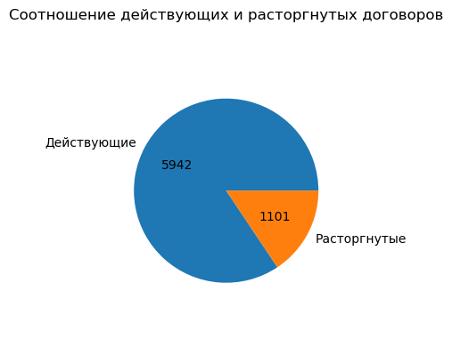

```python
# анализ распределений действующих и закончившихся договоров

display(data['Ended'].value_counts())

value_counts = data['Ended'].value_counts()

plt.pie(value_counts, labels=['Действующие', 'Расторгнутые'], radius=0.7,
        autopct=lambda p: '{:.0f}'.format(p * len(contract_data) / 100))
plt.title('Соотношение действующих и расторгнутых договоров')
plt.savefig('pie_act_end_contracts.png')
plt.show()
```

В предоставленных данных о договорах большинство - действующие, т.о. наблюдается дисбаланс классов (примерно 5 к 1), что необходимо учесть при обучении модели.

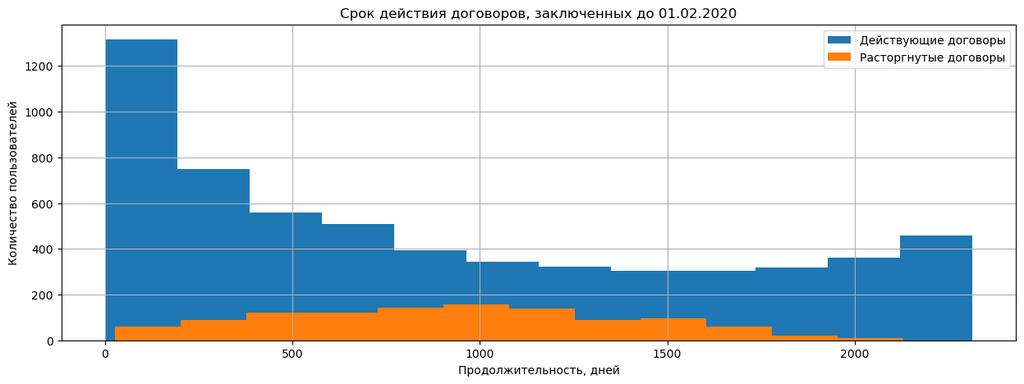

```python
# анализ распределения сроков действия договоров

active_contracts = data[data['Ended'] == '0']
ended_contracts = data[data['Ended'] == '1']

active_contracts['DurationDays'].hist(bins = 12, figsize = (15,5), label='Действующие договоры')
ended_contracts['DurationDays'].hist(bins = 12, figsize = (15,5), label='Расторгнутые договоры')
plt.title('Срок действия договоров, заключенных до 01.02.2020')
plt.xlabel('Продолжительность, дней')
plt.ylabel('Количество пользователей')
plt.legend()
plt.savefig('pie_contracts_period.png')
plt.show();
```

Гистограмма показывает, что в последнее полугодие появилось большое количество новых договоров. При этом имеется также достаточное количество договоров, действующих более 1500 дней, т.е. выше 4 лет - сопоставимое с 2х-летними и превышающее 3х-летние договоры.

Расторгаются в основном договоры, действовавшие от 750 до 1250 дней. При этом нельзя сказать, что компания столкнулась с массовым оттоком клиентов, т.к. количество действующих договоров на порядок выше расторгнутых за исключением указанного периода в 2 - 3,5 года, когда отток клиентов достигает от трети до половины всего объема действующих договоров.

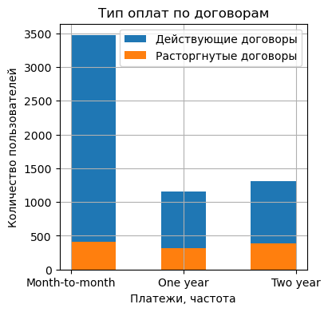

```python
# анализ распределения типов платежей по договорам

active_contracts['Type'].hist(bins = 5, figsize = (4,4), label='Действующие договоры')
ended_contracts['Type'].hist(bins = 5, figsize = (4,4), label='Расторгнутые договоры')
plt.title('Тип оплат по договорам')
plt.xlabel('Платежи, частота')
plt.ylabel('Количество пользователей')
plt.legend()
plt.savefig('hist_payment_period_types.png')
plt.show();
```

На гистограмме распределения количества клиентов по типу оплат видно, что:

- большинство клиентов предпочитают проводить оплату на ежемесячной основе,
- в целом расторжение договоров происходит с одинаковой частотой по каждому типу, но несущественно реже расторгаются договоры с платежом раз в год.

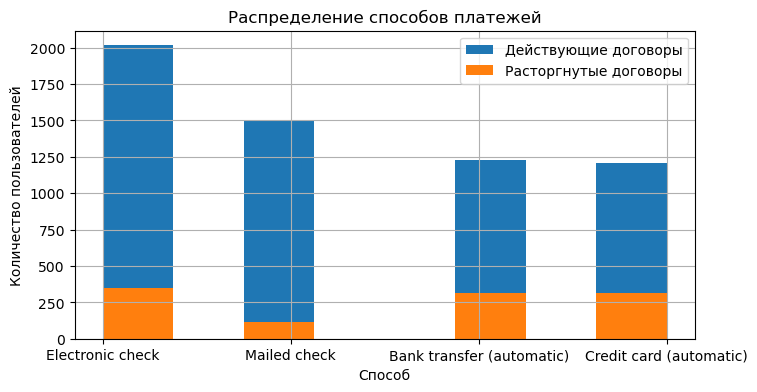

```python
# анализ распределения способов платежей по договорам

active_contracts['PaymentMethod'].hist(bins = 8, figsize = (8,4), label='Действующие договоры')
ended_contracts['PaymentMethod'].hist(bins = 8, figsize = (8,4), label='Расторгнутые договоры')
plt.title('Распределение способов платежей')
plt.xlabel('Способ')
plt.ylabel('Количество пользователей')
plt.legend()
plt.savefig('hist_payments_methods.png')
plt.show();
```

На гистограмме распределения количества клиентов по способу оплат видно, что:

- большинство клиентов предпочитают выписывать электронный чек на оплату,
- клиенты, оформляющие оплату путем отправки чека по почте, существенно реже расторгали договоры несмотря на то, что таких клиентов немного больше, чем клиентов, производящих оплату путем автоматических банковских переводов или переводов с кредитной карты.

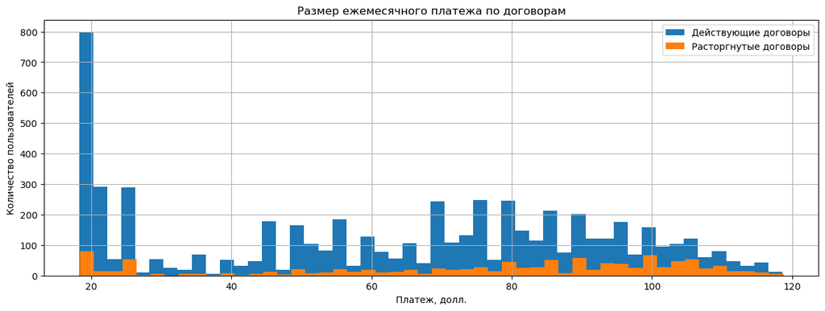

```python
# анализ распределения ежемесячного платежа по договорам

active_contracts['MonthlyCharges'].hist(bins = 50, figsize = (15,5), label='Действующие договоры')
ended_contracts['MonthlyCharges'].hist(bins = 50, figsize = (15,5), label='Расторгнутые договоры')
plt.title('Размер ежемесячного платежа по договорам')
plt.xlabel('Платеж, долл.')
plt.ylabel('Количество пользователей')
plt.legend()
plt.savefig('hist_monthly_charges.png')
plt.show();
```

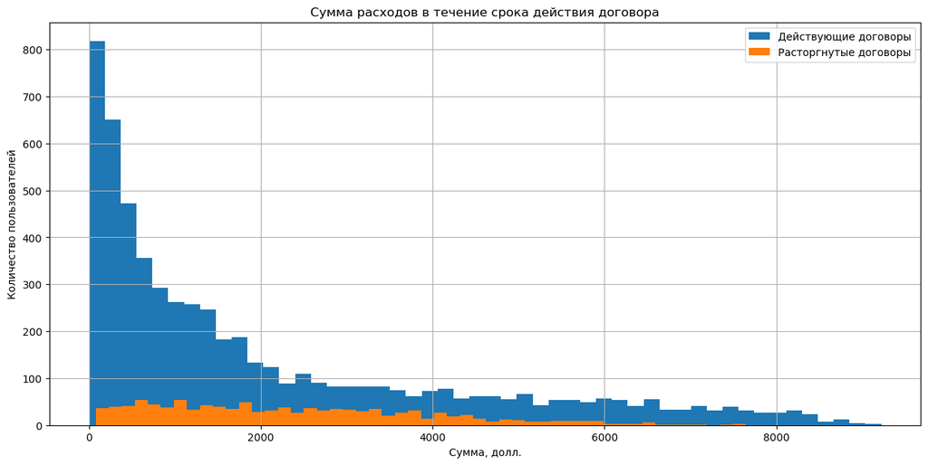

```python
# анализ распределения расходов по договорам

active_contracts['TotalCharges'].hist(bins = 50, figsize = (15,7), label='Действующие договоры')
ended_contracts['TotalCharges'].hist(bins = 50, figsize = (15,7), label='Расторгнутые договоры')
plt.title('Сумма расходов в течение срока действия договора')
plt.xlabel('Сумма, долл.')
plt.ylabel('Количество пользователей')
plt.legend()
plt.savefig('hist_total_charges.png')
plt.show();
```

На гистограмме распределения количества клиентов по сумме расходов в течение срока действия договора видно, что клиенты, потратившие на услуги более 4,5 тыс.долл. менее склонны расторгать договор.

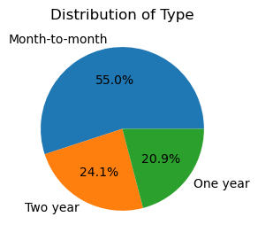

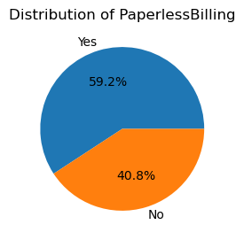

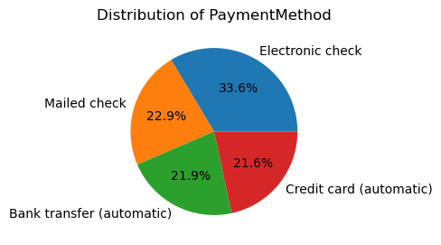

```python
# анализ типа оплат, выставления счёта и способа платежа по информации о договорах в % соотношении

columns = ['Type', 'PaperlessBilling', 'PaymentMethod']

for column in columns:
    plt.figure(figsize=(3, 3))
    plt.title(f'Distribution of {column}')
    df = data[column].value_counts()
    plt.pie(df, labels=df.index, autopct='%1.1f%%')
    plt.show()
```

На основании представленных круговых диаграмм можно сделать вывод, что:

- более половины клиентов предпочитают ежемесячную оплату, 21% - ежегодную и 24% готовы заключить контракт на два года;
- 41% клиентов не готовы отказаться от бумажного счёта, в то время как остальная часть уже получает электронные расчетные листы;
- треть клиентов оплачивает услуги электронным чеком, чуть менее популярны такие способы оплаты как отправка бумажного чека (23% клиентов) и автоматические банковские переводы и оплаты картами (по 22%).

Предположительно, для машинного обучения не будет релевантной информация о необходимости бумажного счёта, столбец PaperlessBilling, т.к. вероятно, заказчик хранит такой признак, чтобы выделить клиентов, для которых нужно напечатать и отправить счёт по почте (т.е. не для анализа и последующей обработки). Данный столбец будет исключен на этапе подготовки данных к обучению.

### Анализ данных о клиентах

```
gender
Male      3555
Female    3488
Name: count, dtype: int64
```

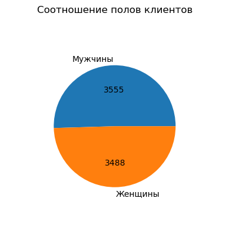

```python
# анализ распределений данных о поле клиентов

display(data['gender'].value_counts())

value_counts = data['gender'].value_counts()

plt.pie(value_counts, radius = 0.7,
        labels=['Мужчины', 'Женщины'], autopct=lambda p: '{:.0f}'.format(p * len(data) / 100))
plt.title('Соотношение полов клиентов')
plt.show();
```

```
SeniorCitizen
0    5901
1    1142
Name: count, dtype: int64
```

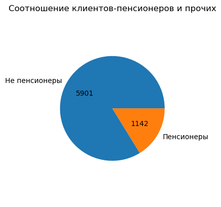

```python
# анализ распределений данных о возрасте клиентов

display(data['SeniorCitizen'].value_counts())

value_counts = data['SeniorCitizen'].value_counts()

plt.pie(value_counts, radius = 0.7,
        labels=['Не пенсионеры', 'Пенсионеры'], autopct=lambda p: '{:.0f}'.format(p * len(data) / 100))
plt.title('Соотношение клиентов-пенсионеров и прочих')
plt.show();
```

```
Partner
No     3641
Yes    3402
Name: count, dtype: int64
```

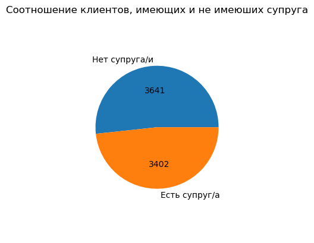

```python
# анализ распределений данных о наличии супругов

display(data['Partner'].value_counts())

value_counts = data['Partner'].value_counts()

plt.pie(value_counts, radius = 0.7
        ,labels=['Нет супруга/и', 'Есть супруг/a'],autopct=lambda p: '{:.0f}'.format(p * len(data) / 100))
plt.title('Соотношение клиентов, имеющих и не имеюших супруга')
plt.show();
```

```
Dependents
No     4933
Yes    2110
Name: count, dtype: int64
```

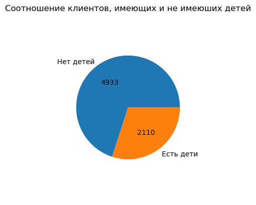

```python
# анализ распределений данных о наличии детей

display(data['Dependents'].value_counts())

value_counts = data['Dependents'].value_counts()

plt.pie(value_counts,radius = 0.7,
        labels=['Нет детей', 'Есть дети'],autopct=lambda p: '{:.0f}'.format(p * len(data) / 100))
plt.title('Соотношение клиентов, имеющих и не имеюших детей')
plt.show();
```

Социальное положение клиентов следующее:

1. У компании примерно одинаковое количество клиентов-мужчин и женщин.
2. Большинство клиентов не является пенсионерами.
3. Соотношение клиентов, имеющих супругов и не имеющих супругов, примерно одинаковое.
4. Примерно треть клиентов имеют детей.

Из группы персональных данных клиентов не предполагается удаление признаков для последующего машинного обучения, т.к. каждый из признаков - пол, косвенный возраст, наличие супругов и иждивенцев, может влиять на объем потребляемых услуг, соответственно, их стоимость, а также на срок заключения договора. Возможно, между указанными признаками будет наблюдаться корреляция - исследуем её далее в рамках данного шага.

### Анализ данных о потребляемых услугах

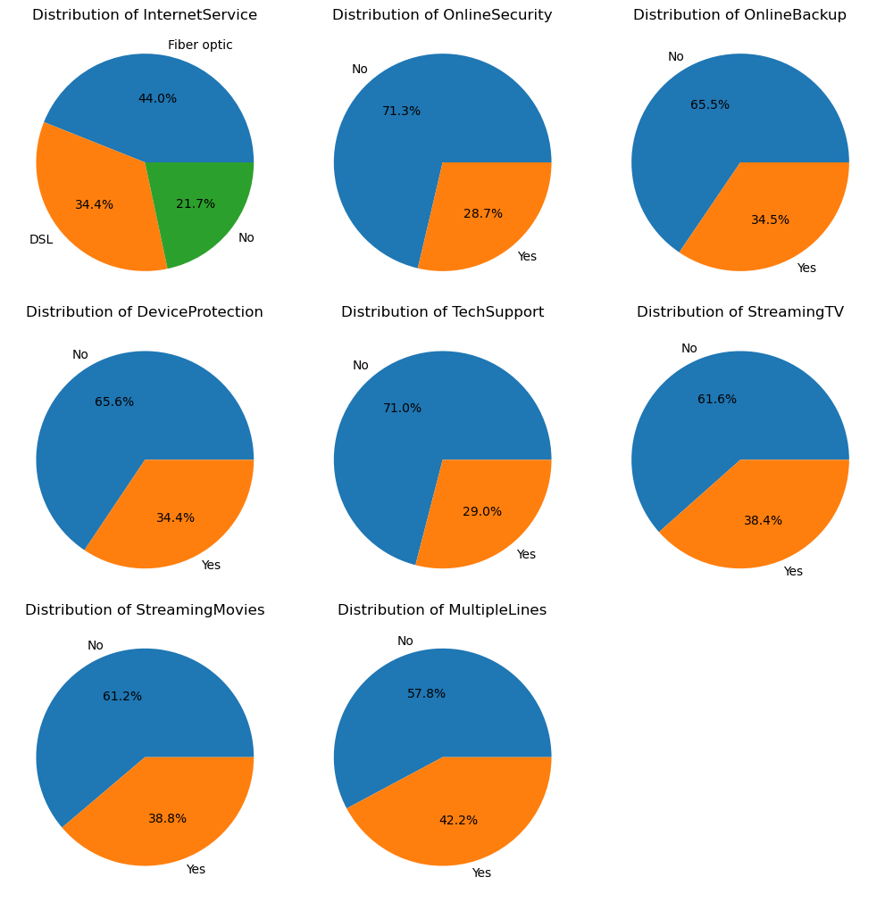

```python
# по комментарию тимлида добавлен код для графиков в насколько строк

fig, axs = plt.subplots(nrows=3, ncols=3, figsize=(10, 10), constrained_layout=True)

columns = ['InternetService', 'OnlineSecurity', 'OnlineBackup', 'DeviceProtection', 'TechSupport',
           'StreamingTV', 'StreamingMovies', 'MultipleLines']

if len(columns) < 9:
    axs[-1, -1].remove()

for i, column in enumerate(columns):
    row = i // 3
    col = i % 3
    ax = axs[row, col]
    df = data[column].value_counts()
    ax.pie(df, labels=df.index, autopct='%1.1f%%')
    ax.set_title(f'Distribution of {column}')
plt.show()
```

Представленные круговые диаграммы показывают, что все предоставляемые заказчиком услуги являются востребованными - не менее четверти клиентов используют какую-либо услугу:

- более всего популярна услуга подключения телефона к нескольким линиям одновременно, её используют более 42% клиентов;
- наименее востребованные услуги - выделенная линия технической поддержки и по блокировке опасных сайтов, их используют около 29% клиентов;
- предоставление услуг облачного хранилища файлов, антивируса, стримингового телевидения и каталога фильмов востребованы у 34-39% клиентов.

Возможно, на набор услуг оказывают влияние социальные статусы клиентов. Исследуем более детально взаимосвязи между данными.

Также на графике видно, что у около пятой части клиентов не указан тип подключения - т.к. это достаточно большая доля пропусков, и их нельзя заполнить случайными данными, что может исказить машинное обучение, то предлагается удалить этот столец на этапе подготовки данных для модели.

### Анализ корреляции

```
interval columns not set, guessing: ['MonthlyCharges', 'TotalCharges', 'SeniorCitizen', 'DurationDays']
```

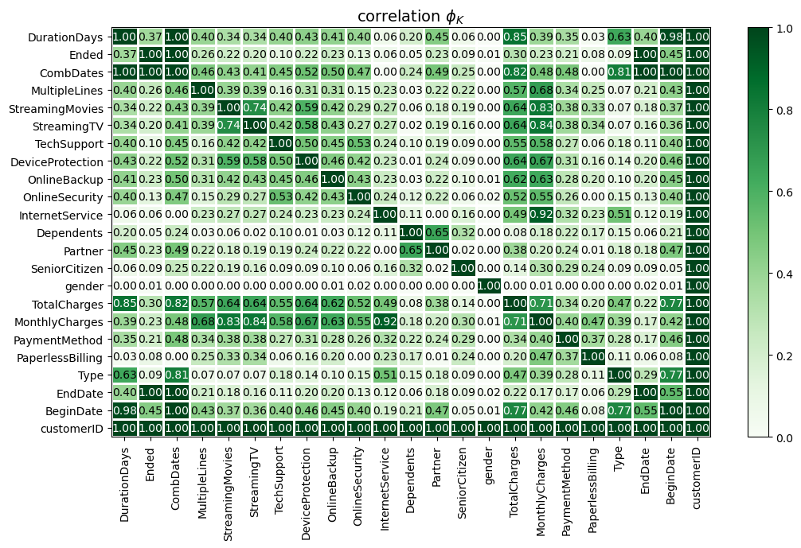

```python
# проверка мультиколлинеарности признаков

phik_overview = data.phik_matrix()

plot_correlation_matrix(phik_overview.values,
                        x_labels=phik_overview.columns,
                        y_labels=phik_overview.index,
                        vmin=0, vmax=1, color_map="Greens",
                        title=r"correlation $\phi_K$",
                        fontsize_factor=1,
                        figsize=(11, 7))
plt.savefig('сorrelation_heatmap.png')
plt.tight_layout()
```

Тепловая карта показывает сильную взаимосвязь некоторых признаков:

- стоимостные показатели расходов за месяц и накопительно за весь период, зависят от видов и объемов потребляемых услуг;
- дата начала и, ожидаемо, дата окончания (включая сводный признак дат) влияют на признак является ли договор расторгнутым и на срок действия договора.

С целевым признаком ярко выраженная корреляция отсуствует (за исключением признака - дата окончания договора и сводного показателя дат начала и окончания договора). Поэтому для обучения модели будут использоваться почти все имеющиеся в датасете признаки после удаления столбцов, обозначенных выше, на этапе подготовки данных.

### Промежуточный вывод

В рамках данного шага были добавлены два новых признака:

- бинарный признак окончания договора,
- численный признак, сколько лет клиенты являются клиентами заказчика.

Также проведены следующие виды анализа:

**Анализ информации о договорах**, который показал, что:

1. В предоставленных данных о договорах большинство - действующие, т.о. наблюдается дисбаланс классов (примерно 5 к 1), что необходимо учесть при обучении модели.
1. Гистограмма распределения данных о сроке действия договора показала:
- в последнее полугодие появилось большое количество новых договоров. При этом имеется также достаточное количество договоров, действующих более 1500 дней, т.е. выше 4 лет - сопоставимое с 2х-летними и превышающее 3х-летние договоры;
- расторгаются в основном договоры, действовавшие от 750 до 1250 дней. При этом нельзя сказать, что компания столкнулась с массовым оттоком клиентов, т.к. количество действующих договоров на порядок выше расторгнутых за исключением указанного периода в 2 - 3,5 года, когда отток клиентов достигает от трети до половины всего объема действующих договоров.
1. На гистограмме распределения количества клиентов по размеру ежемесячного платежа видно, что:
- у большинства клиентов ежемесячный платёж не превышает 30 долларов;
- клиентов, оплачивающих ежемесячно около 100 долларов и расторгащих договоры, примерно столько же как и клиентов с ежемесячным платежом в 20 долларов, несмотря на то, что последних в несколько раз больше;
- наиболее редко расторгают договоры клиенты с платежом примерно от 25 до 70 долларов.
1. На основе гистограммы распределения количества клиентов по сумме расходов в течение срока действия договора можно сделать вывод, что клиенты, потратившие на услуги более 4,5 тыс.долл., менее склонны расторгать договор.
2. На гистограмме распределения количества клиентов по типу оплат видно, что:
- большинство клиентов предпочитают проводить оплату на ежемесячной основе,
- в целом расторжение договоров происходит с одинаковой частотой по каждому типу, но несущественно реже расторгаются договоры с платежом раз в год.
1. На гистограмме распределения количества клиентов по способу оплат видно, что:
- большинство клиентов предпочитают выписывать электронный чек на оплату,
- клиенты, оформляющие оплату путем отправки чека по почте, существенно реже расторгали договоры несмотря на то, что таких клиентов немного больше, чем клиентов, производящих оплату путем автоматических банковских переводов или переводов с кредитной карты.
1. Кроме того анализ показал, что:
- более половины клиентов предпочитают вносить платежи ежемесячно, 21% - ежегодно и 24% готовы платить сразу за два года;
- 41% клиентов не готовы отказаться от бумажного счёта, в то время как остальная часть уже получает электронные расчетные листы;
- треть клиентов оплачивает услуги электронным чеком, менее популярны такие способы оплаты как отправка бумажного чека (23% клиентов) и автоматические банковские переводы и оплаты картами (по 22%)

Предположительно, для машинного обучения не будет релевантной информация о необходимости бумажного счёта, столбец PaperlessBilling, т.к. вероятно, заказчик хранит такой признак, чтобы выделить клиентов, для которых нужно напечатать и отправить счёт по почте (не для анализа и последующей обработки). Данный столбец будет исключен на этапе подготовки данных к обучению.

**Анализ социальных данных клиентов**, который показал следующее:

- у компании примерно одинаковое количество клиентов-мужчин и женщин;
- большинство клиентов не является пенсионерами;
- соотношение клиентов, имеющих супругов и не имеющих супругов, примерно одинаковое;
- примерно треть клиентов имеют детей.

**Анализ данных о потребляемых услугах** показал что все предоставляемые заказчиком услуги являются востребованными - не менее четверти клиентов используют какую-либо услугу:

- более всего популярна услуга подключения телефона к нескольким линиям одновременно, её используют более 42% клиентов;
- наименее востребованные услуги - выделенная линия технической поддержки и по блокировке опасных сайтов, их используют около 29% клиентов;
- предоставление услуг облачного хранилища файлов, антивируса, стримингового телевидения и каталога фильмов востребованы у 34-39% клиентов. Возможно, на набор услуг оказывают влияние социальные статусы клиентов. Исследуем более детально взаимосвязи между данными в рамках анализа корреляции далее.

Также на круговой диаграмме распределения клиентов по видам подключения видно, что у около пятой части клиентов не указан тип подключения - т.к. это достаточно большая доля пропусков, и их нельзя заполнить случайными данными, что может исказить машинное обучение, то предлагается удалить этот столец на этапе подготовки данных для модели.

**Анализ корреляции** был проведен с помощью инструментов библиотеки phik - была построена тепловая карта взаимосяызей между всеми признаками в датасете. Тепловая карта показала сильную взаимосвязь некоторых признаков:

- стоимостные показатели расходов за месяц и накопительно за весь период, зависят от видов и объемов потребляемых услуг;
- дата начала и, ожидаемо, дата окончания влияют на признак является ли договор расторгнутым и на срок действия договора.

С целевым признаком ярко выраженная корреляция отсуствует (за исключением признака - дата окончания договора). Поэтому для обучения модели будут использоваться почти все имеющиеся в датасете признаки после удаления столбцов, обозначенных выше, на этапе подготовки данных.

## Подготовка данных для обучения

### Подготовка датасета

```python
# исключение нерелевантных столбцов и проверка на явные дубликаты

df = data.drop(['customerID', 'BeginDate', 'EndDate', 'PaperlessBilling', 'InternetService', 'CombDates', 'gender'], axis = 1)

'Количество дубликатов:', df.duplicated().sum()
```

```
('Количество дубликатов:', 22)
```

```python
# исключение дубликатов

df = df.drop_duplicates()
display('Количество дубликатов:', df.duplicated().sum())
df.info()
```

```
'Количество дубликатов:'
```

```
0
```

```
<class 'pandas.core.frame.DataFrame'>
Index: 7021 entries, 0 to 7042
Data columns (total 16 columns):
 #   Column            Non-Null Count  Dtype
---  ------            --------------  -----
 0   Type              7021 non-null   object
 1   PaymentMethod     7021 non-null   object
 2   MonthlyCharges    7021 non-null   float64
 3   TotalCharges      7021 non-null   float64
 4   SeniorCitizen     7021 non-null   int64
 5   Partner           7021 non-null   object
 6   Dependents        7021 non-null   object
 7   OnlineSecurity    7021 non-null   object
 8   OnlineBackup      7021 non-null   object
 9   DeviceProtection  7021 non-null   object
 10  TechSupport       7021 non-null   object
 11  StreamingTV       7021 non-null   object
 12  StreamingMovies   7021 non-null   object
 13  MultipleLines     7021 non-null   object
 14  Ended             7021 non-null   object
 15  DurationDays      7021 non-null   int64
dtypes: float64(2), int64(2), object(12)
memory usage: 932.5+ KB
```

В рамках данного шага:

- удалены неревантные для обученя признаки - идентификационный номер клиента, его пол, отметка о необходимости отправки электронного расчётного листа, даты начала и окончания договоров, информация о типе подключения и сводный признак даты;
- данные повторно проверены, из них исключены новые дубликаты.

### Разделение на выборки и признаки

```python
# разделение на выборки и проверка размеров


df_train, df_test = train_test_split(df, test_size=0.25, random_state=RANDOM_STATE, stratify=df['Ended'])

print('Размер обучающей выборки:', df_train.shape)
print('Размер тестовой выборки:', df_test.shape)
```

```
Размер обучающей выборки: (5265, 16)
Размер тестовой выборки: (1756, 16)
```

```python
# выделение признаков и проверка размеров таблиц

features_train = df_train.drop(['Ended'], axis=1)
target_train = df_train['Ended']

features_test = df_test.drop(['Ended'], axis=1)
target_test = df_test['Ended']

print('Размеры таблиц:')
print(features_train.shape)
print(target_train.shape)
print(features_test.shape)
print(target_test.shape)
```

```
Размеры таблиц:
(5265, 15)
(5265,)
(1756, 15)
(1756,)
```

В рамках данного шага:

- данные разделены на обучающую и тестовую выборку в пропорции 3:1,
- из выборок выделены обучающие и целевой признаки.

### Кодирование

Для машинного обучения выберем:

```python
#создание датасета и категориальных признаков для OE-кодирования

features_train_oe = features_train.copy()

categories = features_train_oe.select_dtypes(include='object').columns.to_list()

features_train_oe.head()
```

|  | Type | PaymentMethod | MonthlyCharges | TotalCharges | SeniorCitizen | Partner | Dependents | OnlineSecurity | OnlineBackup | DeviceProtection | TechSupport | StreamingTV | StreamingMovies | MultipleLines | DurationDays |
| --- | --- | --- | --- | --- | --- | --- | --- | --- | --- | --- | --- | --- | --- | --- | --- |
| 5462 | One year | Mailed check | 70.15 | 4489.60 | 0 | Yes | No | No | Yes | No | Yes | No | Yes | Yes | 1949 |
| 3419 | Two year | Mailed check | 92.15 | 6358.35 | 0 | Yes | Yes | No | Yes | No | Yes | Yes | No | No | 2102 |
| 369 | Two year | Credit card (automatic) | 112.60 | 8755.78 | 0 | Yes | Yes | Yes | Yes | Yes | Yes | Yes | Yes | Yes | 2191 |
| 2138 | Two year | Bank transfer (automatic) | 69.95 | 4079.48 | 0 | Yes | Yes | Yes | No | Yes | Yes | No | Yes | No | 1645 |
| 1867 | Month-to-month | Electronic check | 83.75 | 633.15 | 0 | No | No | No | Yes | No | No | Yes | No | No | 215 |

```python
# создание энкодера и кодирование категориальных признаков

encoder_oe = OrdinalEncoder(handle_unknown='use_encoded_value', unknown_value=-1)
encoder_oe.fit(features_train_oe[categories])
```

```
OrdinalEncoder(handle_unknown='use_encoded_value', unknown_value=-1)
```

```python
# кодирование обучающей выборки

features_train_oe[encoder_oe.get_feature_names_out()] = encoder_oe.transform(features_train[categories])
features_train_oe.head()
```

|  | Type | PaymentMethod | MonthlyCharges | TotalCharges | SeniorCitizen | Partner | Dependents | OnlineSecurity | OnlineBackup | DeviceProtection | TechSupport | StreamingTV | StreamingMovies | MultipleLines | DurationDays |
| --- | --- | --- | --- | --- | --- | --- | --- | --- | --- | --- | --- | --- | --- | --- | --- |
| 5462 | 1.0 | 3.0 | 70.15 | 4489.60 | 0 | 1.0 | 0.0 | 0.0 | 1.0 | 0.0 | 1.0 | 0.0 | 1.0 | 1.0 | 1949 |
| 3419 | 2.0 | 3.0 | 92.15 | 6358.35 | 0 | 1.0 | 1.0 | 0.0 | 1.0 | 0.0 | 1.0 | 1.0 | 0.0 | 0.0 | 2102 |
| 369 | 2.0 | 1.0 | 112.60 | 8755.78 | 0 | 1.0 | 1.0 | 1.0 | 1.0 | 1.0 | 1.0 | 1.0 | 1.0 | 1.0 | 2191 |
| 2138 | 2.0 | 0.0 | 69.95 | 4079.48 | 0 | 1.0 | 1.0 | 1.0 | 0.0 | 1.0 | 1.0 | 0.0 | 1.0 | 0.0 | 1645 |
| 1867 | 0.0 | 2.0 | 83.75 | 633.15 | 0 | 0.0 | 0.0 | 0.0 | 1.0 | 0.0 | 0.0 | 1.0 | 0.0 | 0.0 | 215 |

```python
# кодирование тестовой выборки

features_test_oe = features_test.copy()

features_test_oe[encoder_oe.get_feature_names_out()] = encoder_oe.transform(features_test_oe[categories])
features_test_oe.head()
```

|  | Type | PaymentMethod | MonthlyCharges | TotalCharges | SeniorCitizen | Partner | Dependents | OnlineSecurity | OnlineBackup | DeviceProtection | TechSupport | StreamingTV | StreamingMovies | MultipleLines | DurationDays |
| --- | --- | --- | --- | --- | --- | --- | --- | --- | --- | --- | --- | --- | --- | --- | --- |
| 6216 | 2.0 | 1.0 | 71.60 | 4152.80 | 0 | 1.0 | 1.0 | 1.0 | 1.0 | 1.0 | 1.0 | 0.0 | 0.0 | 1.0 | 1767 |
| 1913 | 1.0 | 2.0 | 95.50 | 6207.50 | 0 | 0.0 | 0.0 | 0.0 | 1.0 | 1.0 | 0.0 | 1.0 | 0.0 | 1.0 | 1979 |
| 2513 | 2.0 | 3.0 | 19.20 | 1018.37 | 0 | 1.0 | 1.0 | 0.0 | 0.0 | 0.0 | 0.0 | 0.0 | 0.0 | 0.0 | 1584 |
| 6306 | 1.0 | 0.0 | 116.30 | 8422.45 | 0 | 0.0 | 0.0 | 1.0 | 1.0 | 1.0 | 1.0 | 1.0 | 1.0 | 1.0 | 2163 |
| 3387 | 0.0 | 3.0 | 20.65 | 148.89 | 0 | 0.0 | 0.0 | 0.0 | 0.0 | 0.0 | 0.0 | 0.0 | 0.0 | 0.0 | 215 |

```python
#  проверка размеров выборок

print(features_train_oe.shape)
print(features_test_oe.shape)
```

```
(5265, 15)
(1756, 15)
```

```python
# исправление типов данных в таблицах с целевым признаком

target_train = target_train.astype(int)
target_test = target_test.astype(int)
```

Данные закодированы, размеры выборок не изменились.

### Масштабирование

```python
# добавляем масштабирование для логистической регрессии

scaler = MinMaxScaler(feature_range=(0, 1))

features_train_oe_scaled = scaler.fit_transform(features_train_oe)
features_test_oe_scaled = scaler.transform(features_test_oe)

features_train_oe_scaled.shape, features_test_oe_scaled.shape
```

```
((5265, 15), (1756, 15))
```

Добавлено масштабирование для использования в модели логистической регрессии.

### Категории для LGBM модели

```python
# создание датафреймов для присвоения категорий столбцам

features_train_ctg = features_train.copy()
features_test_ctg = features_test.copy()

print(features_train_ctg.shape)
print(features_test_ctg.shape)
```

```
(5265, 15)
(1756, 15)
```

```python
# присвоение категорий столбцам

features_train_ctg[categories] = features_train_ctg[categories].astype('category')
features_test_ctg[categories] = features_test_ctg[categories].astype('category')

features_train_ctg.info(), features_test_ctg.info()
```

```
<class 'pandas.core.frame.DataFrame'>
Index: 5265 entries, 5462 to 4418
Data columns (total 15 columns):
 #   Column            Non-Null Count  Dtype
---  ------            --------------  -----
 0   Type              5265 non-null   category
 1   PaymentMethod     5265 non-null   category
 2   MonthlyCharges    5265 non-null   float64
 3   TotalCharges      5265 non-null   float64
 4   SeniorCitizen     5265 non-null   int64
 5   Partner           5265 non-null   category
 6   Dependents        5265 non-null   category
 7   OnlineSecurity    5265 non-null   category
 8   OnlineBackup      5265 non-null   category
 9   DeviceProtection  5265 non-null   category
 10  TechSupport       5265 non-null   category
 11  StreamingTV       5265 non-null   category
 12  StreamingMovies   5265 non-null   category
 13  MultipleLines     5265 non-null   category
 14  DurationDays      5265 non-null   int64
dtypes: category(11), float64(2), int64(2)
memory usage: 263.6 KB
<class 'pandas.core.frame.DataFrame'>
Index: 1756 entries, 6216 to 5392
Data columns (total 15 columns):
 #   Column            Non-Null Count  Dtype
---  ------            --------------  -----
 0   Type              1756 non-null   category
 1   PaymentMethod     1756 non-null   category
 2   MonthlyCharges    1756 non-null   float64
 3   TotalCharges      1756 non-null   float64
 4   SeniorCitizen     1756 non-null   int64
 5   Partner           1756 non-null   category
 6   Dependents        1756 non-null   category
 7   OnlineSecurity    1756 non-null   category
 8   OnlineBackup      1756 non-null   category
 9   DeviceProtection  1756 non-null   category
 10  TechSupport       1756 non-null   category
 11  StreamingTV       1756 non-null   category
 12  StreamingMovies   1756 non-null   category
 13  MultipleLines     1756 non-null   category
 14  DurationDays      1756 non-null   int64
dtypes: category(11), float64(2), int64(2)
memory usage: 88.9 KB
```

```
(None, None)
```

В рамках данного шага присвоены категории столбцам для последующего использования в LGBM модели.

### Промежуточный вывод

Подготовка данных была проведена следующим образом:

1. Обработка основного датасета:
- создан синтетический столбец, объединящий даты начала и окончания договоров, из которого возможно в последюущем выделить указанные даты;
- удалены неревантные для обученя признаки - идентификационный номер клиента, отметка о необходимости отправки электронного расчётного листа, даты начала и окончания договоров, информация о типе подключения;
- данные повторно проверены, из них исключены новые дубликаты.
1. Разделение данных:
- данные разделены на обучающую и тестовую выборку в пропорции 3:1,
- из выборок выделены обучающие и целевой признаки.
1. Кодирование

Для машинного обучения выбраны:

- Модель дерева решений,
- Модель случайного леса,
- Модель логистической регрессии,
- Модель LightGBM,
- Модель CatBoost.

Из предложенных моделей только модели бустинга, LightGBM и CatBoost, имеют встроенный инструмент кодирования. Для обучения "деревянных" моделей и логистической регрессии проведено кодирование на основании следующих данных:

- поскольку вариативность признаков минимальная (yes/no), то применим порядковое кодирование;
- так как модель дерева решений не является чувствительной к масштабу данных (пороги разбиений выбираются в зависимости от значений признаков);
- на этапе анализа был выявлен дисбаланс классов, поэтому в каждой из моделей будет использован встроенный инструмент балансировки классов.
1. Для последующего использования в LGBM модели были присвоены категории столбцам, содержащим категориальные признаки.
1. Добавлено масштабирование данных в диапазоне 0, 1 для использования в модели логистической регрессии.

## Обучение моделей

### Модель дерева решений

```python
# создание модели

model_dt = DecisionTreeClassifier(class_weight = 'balanced', random_state = RANDOM_STATE)
```

```python
# создание пайплайна и поиск лучших параметров

pipeline_dt = make_pipeline(encoder_oe, model_dt)

param_grid_dt = {'decisiontreeclassifier__max_depth': range(1, 21),
                'decisiontreeclassifier__min_samples_leaf': range(1, 3)}

gs_dt_pl = GridSearchCV(
    pipeline_dt,
    param_grid=param_grid_dt,
    scoring='roc_auc',
    n_jobs=-1
)

gs_dt_pl.fit(features_train_oe, target_train)

gs_dt_best_score = gs_dt_pl.best_score_
gs_dt_best_params = gs_dt_pl.best_params_

print(f'best_score: {gs_dt_best_score}')
print(f'best_params: {gs_dt_best_params}')
```

```
best_score: 0.6895366482554921
best_params: {'decisiontreeclassifier__max_depth': 3, 'decisiontreeclassifier__min_samples_leaf': 1}
```

### Модель случайного леса

```python
# создание модели

model_rf = RandomForestClassifier(class_weight = 'balanced', random_state = RANDOM_STATE)
```

```python
# создание пайплайна и поиск лучших параметров

pipeline_rf = make_pipeline(encoder_oe, model_rf)

param_grid_rf = {'randomforestclassifier__max_depth': range(5, 11),
                'randomforestclassifier__n_estimators': range(100, 150, 10)}

gs_rf_pl = GridSearchCV(
    pipeline_rf,
    param_grid=param_grid_rf,
    scoring='roc_auc',
    n_jobs=-1
)

gs_rf_pl.fit(features_train_oe, target_train)

gs_rf_best_score = gs_rf_pl.best_score_
gs_rf_best_params = gs_rf_pl.best_params_

print(f'best_score: {gs_rf_best_score}')
print(f'best_params: {gs_rf_best_params}')
```

```
best_score: 0.8165767715714741
best_params: {'randomforestclassifier__max_depth': 7, 'randomforestclassifier__n_estimators': 140}
```

### Модель логистический регрессии

```python
# создание модели

model_lr = LogisticRegression(class_weight = 'balanced', random_state = RANDOM_STATE)
```

```python
# создание пайплайна и поиск лучших параметров

pipeline_lr = make_pipeline(encoder_oe, model_lr)

param_grid_lr = {'logisticregression__solver': ['lbfgs', 'liblinear', 'newton-cholesky', 'sag', 'saga']}


gs_lr_pl = GridSearchCV(
    pipeline_lr,
    param_grid=param_grid_lr,
    scoring='roc_auc',
    n_jobs=-1
)

gs_lr_pl.fit(features_train_oe_scaled, target_train)

gs_lr_best_score = gs_lr_pl.best_score_
gs_lr_best_params = gs_lr_pl.best_params_


print(f'best_score: {gs_lr_best_score}')
print(f'best_params: {gs_lr_best_params}')
```

```
best_score: 0.566743294488503
best_params: {'logisticregression__solver': 'lbfgs'}
```

### Модель LightGBM

```python
# создание модели LightGBM

model_lgbm = LGBMClassifier(verbose=-1, class_weight = 'balanced', random_state = RANDOM_STATE)
```

```python
# обучение модели LightGBM и подбор параметров

param_grid_lgbm = {'learning_rate': [0.1, 0.5, 0.75],
                   'max_depth': range(1, 10)} # добавлены новые гиперпараметры

gs_lgbm = GridSearchCV(
    model_lgbm,
    param_grid=param_grid_lgbm,
    scoring='roc_auc',
    n_jobs=-1
)

gs_lgbm.fit(features_train_ctg, target_train, categorical_feature=categories)

gs_lgbm_best_score = gs_lgbm.best_score_
gs_lgbm_best_params = gs_lgbm.best_params_

print(f'best_score: {gs_lgbm_best_score}')
print(f'best_params: {gs_lgbm_best_params}')
```

```
best_score: 0.8859667282266133
best_params: {'learning_rate': 0.5, 'max_depth': 3}
```

### Модель CatBoost

```python
# создание модели CatBoost

model_cb = CatBoostClassifier(random_state = RANDOM_STATE)
```

```python
# обучение модели CatBoost и подбор параметров

param_grid_cb = {'iterations': [100, 150, 200, 250, 500],
                 'learning_rate': [0.05, 0.1, 0.5, 0.75]}

gs_cb = GridSearchCV(
    model_cb,
    param_grid=param_grid_cb,
    scoring='roc_auc',
    n_jobs=-1
)

gs_cb.fit(features_train_ctg, target_train, cat_features=categories, verbose=0)

gs_cb_best_score = gs_cb.best_score_
gs_cb_best_params = gs_cb.best_params_

print(f'best_score: {gs_cb_best_score}')
print(f'best_params: {gs_cb_best_params}')
```

```
best_score: 0.9089102453819722
best_params: {'iterations': 500, 'learning_rate': 0.1}
```

```python
# подготовка сводной таблицы результатов

result = pd.DataFrame({
    'AUC-ROC': [gs_cb_best_score, gs_lgbm_best_score, gs_rf_best_score, gs_dt_best_score, gs_lr_best_score],
    'Best Parameters': [gs_cb_best_params, gs_lgbm_best_params, gs_rf_best_params, gs_dt_best_params, gs_lr_best_params]
    },
    index=['CatBoost', 'LGBMClassifier', 'RandomForest', 'DecisionTree', 'LogisticRegression']
)
pd.set_option('display.max_colwidth', None)
result
```

|  | AUC-ROC | Best Parameters |
| --- | --- | --- |
| CatBoost | 0.908910 | {'iterations': 500, 'learning_rate': 0.1} |
| LGBMClassifier | 0.885967 | {'learning_rate': 0.5, 'max_depth': 3} |
| RandomForest | 0.816577 | {'randomforestclassifier__max_depth': 7, 'randomforestclassifier__n_estimators': 140} |
| DecisionTree | 0.689537 | {'decisiontreeclassifier__max_depth': 3, 'decisiontreeclassifier__min_samples_leaf': 1} |
| LogisticRegression | 0.566743 | {'logisticregression__solver': 'lbfgs'} |

### Промежуточный вывод

В рамках данного шага были обучены модели, основанные на алгоритмах:

- дерева решений,
- случайного леса,
- логистической регресии,
- градиентного бустинга Light GBM,
- градиентного бустинга CatBoost.

С использованием инструментов пайплана и поиска по сетке была проведена кросс-валидация качества моделей на обучающей выборке.

Ниже представлены результаты обучения моделей - величина показателя AUC-ROC, которой был установлен как порог оценки качества модели в размере 0.85.

|  | AUC-ROC | Best Parameters |
| --- | --- | --- |
| CatBoost | 0.908910 | {'iterations': 500, 'learning_rate': 0.1} |
| LGBMClassifier | 0.885967 | {'learning_rate': 0.5, 'max_depth': 3} |
| RandomForest | 0.816577 | {'randomforestclassifier**max_depth': 7, 'randomforestclassifier**n_estimators': 140} |
| DecisionTree | 0.689537 | {'decisiontreeclassifier**max_depth': 3, 'decisiontreeclassifier**min_samples_leaf': 1} |
| LogisticRegression | 0.566743 | {'logisticregression__solver': 'lbfgs'} |

Лучший результат продемонстрировала модель CatBoost, которая будет проверена на тестовой выборке.

## Выбор лучшей модели

### Тестирование лучшей модели

```python
# создание модели CatBoost с лучшими параметрами и оценка на тестовой выборке

model_cb_final = CatBoostClassifier(random_state=RANDOM_STATE, iterations=500, learning_rate=0.1)

model_cb_final.fit(features_train_ctg, target_train, cat_features=categories, verbose=0)

cb_probabilities_test = model_cb_final.predict_proba(features_test_ctg)

probabilities_one_test = cb_probabilities_test[:, 1]

cb_roc_auc = roc_auc_score(target_test, probabilities_one_test).round(2)
print('AUC-ROC модели CatBoost на тестовой выборке: ', cb_roc_auc)
```

```
AUC-ROC модели CatBoost на тестовой выборке:  0.9
```

С результатом AUC-ROC 0.9 модель CatBoost достигла целевого показателя AUC-ROC на тестовой выборке в размере 0.85. Данная модель может быть рекомендована заказчику для использования при составлении прогноза оттока клиентов.

```python
# расчёт accuracy для лучшей модели

cb_predictions_test = model_cb_final.predict(features_test_ctg)
cb_accuracy = accuracy_score(target_test, cb_predictions_test).round(2)
cb_accuracy
```

```
0.91
```

```python
# подготовка сводной таблицы оценок лучшей модели на тестовой выборке

result_test = pd.DataFrame(
    [cb_roc_auc, cb_accuracy],
    index=['AUC-ROC', 'Accuracy'],
    columns=['Rate']
)
result_test
```

|  | Rate |
| --- | --- |
| AUC-ROC | 0.90 |
| Accuracy | 0.91 |

### Оценка важности показателей

```
Feature: Type, Score: 0.8217180275705892
Feature: PaymentMethod, Score: 1.3211103665412853
Feature: MonthlyCharges, Score: 1.3780976655204804
Feature: TotalCharges, Score: 1.3901919961836469
Feature: SeniorCitizen, Score: 1.4540787405147513
Feature: Partner, Score: 1.6897843738664795
Feature: Dependents, Score: 1.725735687718695
Feature: OnlineSecurity, Score: 1.916221530621196
Feature: OnlineBackup, Score: 3.2760546682559752
Feature: DeviceProtection, Score: 4.087056926395588
Feature: TechSupport, Score: 6.548472232371562
Feature: StreamingTV, Score: 9.067613918754159
Feature: StreamingMovies, Score: 9.885362001183049
Feature: MultipleLines, Score: 11.427111368355408
Feature: DurationDays, Score: 44.01139049614712
```

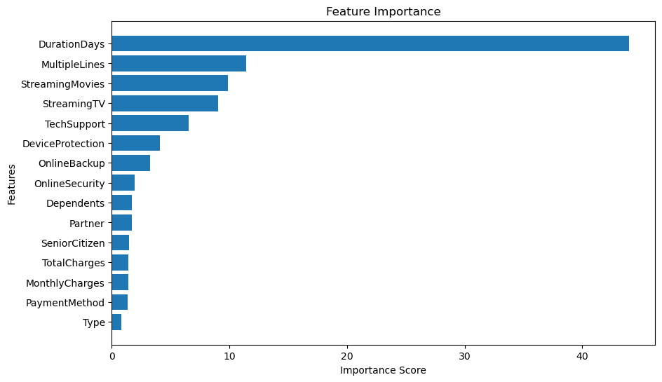

```python
# оценка важности показателей с помощью встроенного метода модели дерева решений

feature_names = features_train_ctg.columns

importance = model_cb_final.feature_importances_

importance = np.sort(importance)

plt.figure(figsize=(10, 6))

for i, v in enumerate(importance):
    print('Feature: {}, Score: {}'.format(feature_names[i], v))

plt.barh(range(len(importance)), importance)
plt.yticks(range(len(importance)), feature_names, rotation=0)
plt.ylabel('Features')
plt.xlabel('Importance Score')
plt.title('Feature Importance')
plt.savefig('hist_importance.png')
plt.show()
```

### График ROC_AUC

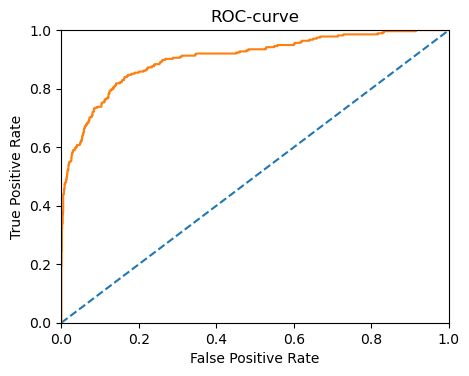

```python
# график ROC_AUC лучшей модели

fpr, tpr, thresholds = roc_curve(target_test, probabilities_one_test)

plt.figure(figsize=(5, 3.8))
plt.plot([0, 1], [0, 1], linestyle='--')
plt.plot(fpr, tpr)
plt.xlim([0.0, 1.0])
plt.ylim([0.0, 1.0])
plt.xlabel('False Positive Rate')
plt.ylabel('True Positive Rate')
plt.title('ROC-curve')
plt.savefig('roc_curve.png')
plt.show()
```

### Построение матрицы ошибок

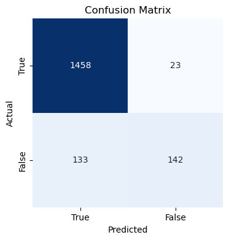

```python
# построение матрицы ошибок

cm = confusion_matrix(target_test, cb_predictions_test)

tick_labels = ['True', 'False']
plt.figure(figsize=(4, 4))
sns.heatmap(cm, annot=True, fmt="d", cmap="Blues", cbar=False, xticklabels=tick_labels, yticklabels=tick_labels)
plt.xlabel('Predicted')
plt.ylabel('Actual')
plt.title('Confusion Matrix')
plt.savefig('confusion_matrix.png')
plt.show()
```

### Промежуточный вывод

Показатели AUC-ROC лучшей модели CatBoost на тестовой выборке приведены ниже:

| Scoring | Rate |
| --- | --- |
| AUC-ROC | 0.90 |
| Accuracy | 0.91 |

## Общий вывод и рекомендации заказчику

Оператор связи «ТелеДом» поланирует бороться с оттоком клиентов путем предоставления промокодов и специальных условий всем, кто планирует отказаться от услуг связи, чтобы заранее находить таких пользователей, «ТелеДому» нужна модель, которая будет предсказывать, разорвёт ли абонент договор.

**Задача:** обучить модель для прогноза оттока клиентов.

Для обучения модели заказчик предоставил персональные данные о некоторых клиентах, информацию об их тарифах и услугах.

**План работы:**

1. Загрузка и первичный обзор данных
2. Предобработка данных
3. Объединение данных
4. Исследовательский анализ и предобработка данных объединённого датафрейма
5. Подготовка данных
6. Обучение моделей машинного обучения
7. Выбор лучшей модели

### Первичных обзор данных

Первичных обзор данных показал следующее:

1. Данные в файле с информацией о договоре соответствуют описанию, не содержат дубликатов и пропусков, при этом тип данных не соответствует содержанию в столбцах BeginDate, EndDate и TotalCharges - это будет изменено на этапе предобработки данных.
2. Данные о клиентах соответствуют описанию, не содержат дубликатов и пропусков, тип данных корректный.
3. Данные об интернет-услугах соответствуют описанию, не содержат дубликатов и пропусков, тип данных корректный. При этом количество записей меньше, чем записей о клиентах и договорах, что может говорить о том, что не все клиенты пользуются интернет-услугами.
4. Данные об услугах телефонии соответствуют описанию, не содержат дубликатов и пропусков, тип данных корректный. При этом количество записей также меньше, что может говорить о том, что не все клиенты пользуются услугами телефонии.

### Предобработка данных

В рамках предобработки данных в файле contract_new были выполнены следующие шаги:

- преобразован тип данных в столбцах, содержащих дату начала и дату окончания договора;
- к действующим договорам в столбце EndDate была добавлена дата выгрузки отчета, с целью полноты преобразования, а также для удобства последующих операций;
- на основе EndDate был добавлен признак, является ли договор действующим или нет, для удобства последующего анализа и обучения модели;
- на основе дат начала и дату окончания договора был добавлен столбец с количеством лет продолжительности действия договора;
- преобразован тип данных в столбце TotalCharges - на числовой, при этом в столбце имелись пропуски, соответствующие договорам, дата начала которых равна дате, на котовую выгружены данные - 01.02.2020, т.е. у данных клиентов к указанной дате ещё не возникло начислений - т.о. пропуски были заполнены нулевым значением.

### Объединение данных

В рамках данного шага проведено присоединение таблиц с персональными данными и информации об интернет-услугах и телефонии к основной таблице с информацией о договорах.

В объединенном датасете появились пропуски, связанные с тем, что не все клиенты используют интернет-услуги и услуги телефонии, поэтому пропуски были заполнены значением No.

### Исследовательский анализ и предобработка данных объединённого датафрейма

В рамках данного шага были добавлены два новых признака:

- бинарный признак окончания договора,
- численный признак, сколько лет клиенты являются клиентами заказчика.

Также проведены следующие виды анализа:

**Анализ информации о договорах**:

[figure not shown]

1. В предоставленных данных о договорах большинство - действующие, т.о. наблюдается дисбаланс классов (примерно 5 к 1), что необходимо учесть при обучении модели.

[figure not shown]

1. Гистограмма распределения клиентов по срокам действия договоров, заключенных до 01.02.2020 показала:
- в последнее полугодие появилось большое количество новых договоров. При этом имеется также достаточное количество договоров, действующих более 1500 дней, т.е. выше 4 лет - сопоставимое с 2х-летними и превышающее 3х-летние договоры;
- расторгаются в основном договоры, действовавшие от 750 до 1250 дней. При этом нельзя сказать, что компания столкнулась с массовым оттоком клиентов, т.к. количество действующих договоров на порядок выше расторгнутых за исключением указанного периода в 2 - 3,5 года, когда отток клиентов достигает от трети до половины всего объема действующих договоров.

[figure not shown]

1. На гистограмме распределения количества клиентов по размеру ежемесячного платежа видно, что:
- у большинства клиентов ежемесячный платёж не превышает 30 долларов;
- клиентов, оплачивающих ежемесячно около 100 долларов и расторгащих договоры, примерно столько же как и клиентов с ежемесячным платежом в 20 долларов, несмотря на то, что последних в несколько раз больше;
- наиболее редко расторгают договоры клиенты с платежом примерно от 25 до 70 долларов.

[figure not shown]

1. На основе гистограммы распределения количества клиентов по сумме расходов в течение срока действия договора можно сделать вывод, что клиенты, потратившие на услуги более 4,5 тыс.долл., менее склонны расторгать договор.

[figure not shown]

1. На гистограмме распределения количества клиентов по типу оплат видно, что:
- большинство клиентов предпочитают проводить оплату на ежемесячной основе,
- в целом расторжение договоров происходит с одинаковой частотой по каждому типу, но несущественно реже расторгаются договоры с платежом раз в год.

[figure not shown]

1. На гистограмме распределения количества клиентов по способу оплат видно, что:
- большинство клиентов предпочитают выписывать электронный чек на оплату,
- клиенты, оформляющие оплату путем отправки чека по почте, существенно реже расторгали договоры несмотря на то, что таких клиентов немного больше, чем клиентов, производящих оплату путем автоматических банковских переводов или переводов с кредитной карты.
1. Кроме того анализ показал, что:
- более половины клиентов предпочитают вносить платежи ежемесячно, 21% - ежегодно и 24% готовы платить сразу за два года;
- 41% клиентов не готовы отказаться от бумажного счёта, в то время как остальная часть уже получает электронные расчетные листы;
- треть клиентов оплачивает услуги электронным чеком, менее популярны такие способы оплаты как отправка бумажного чека (23% клиентов) и автоматические банковские переводы и оплаты картами (по 22%)

Предположительно, для машинного обучения не будет релевантной информация о необходимости бумажного счёта, столбец PaperlessBilling, т.к. вероятно, заказчик хранит такой признак, чтобы выделить клиентов, для которых нужно напечатать и отправить счёт по почте (не для анализа и последующей обработки). Данный столбец будет исключен на этапе подготовки данных к обучению.

**Анализ социальных данных клиентов**, который показал следующее:

- у компании примерно одинаковое количество клиентов-мужчин и женщин;
- большинство клиентов не является пенсионерами;
- соотношение клиентов, имеющих супругов и не имеющих супругов, примерно одинаковое;
- примерно треть клиентов имеют детей.

**Анализ данных о потребляемых услугах** показал что все предоставляемые заказчиком услуги являются востребованными - не менее четверти клиентов используют какую-либо услугу:

- более всего популярна услуга подключения телефона к нескольким линиям одновременно, её используют более 42% клиентов;
- наименее востребованные услуги - выделенная линия технической поддержки и по блокировке опасных сайтов, их используют около 29% клиентов;
- предоставление услуг облачного хранилища файлов, антивируса, стримингового телевидения и каталога фильмов востребованы у 34-39% клиентов. Возможно, на набор услуг оказывают влияние социальные статусы клиентов. Исследуем более детально взаимосвязи между данными в рамках анализа корреляции далее.

Также анаоиз распределения клиентов по видам подключения показал, что у примерно пятой части клиентов не указан тип подключения - т.к. это достаточно большая доля пропусков, и их нельзя заполнить случайными данными, что может исказить машинное обучение, то предлагается удалить этот столец на этапе подготовки данных для модели.

Т.о. можно составить **портрет уходящего клиента** - это человек:

- является клиентом от 2 до 3,5 лет;
- потративший на услуги не более 4,5 тыс.долл. за весь период действия договора;
- предпочитает проводить оплату на ежемесячной основе;
- ежемесячный платёж которого составляет до 25 или более 70 долларов;
- предпочитает проводить оплату путем отправки электронного чека, автоматических банковских переводов или переводов с кредитной карты (не путем отправки бумажного чека).

**Анализ корреляции** был проведен с помощью инструментов библиотеки phik - была построена тепловая карта взаимосяызей между всеми признаками в датасете.

[figure not shown]

Тепловая карта показала сильную взаимосвязь некоторых признаков:

- стоимостные показатели расходов за месяц и накопительно за весь период, зависят от видов и объемов потребляемых услуг;
- дата начала и, ожидаемо, дата окончания, а также сводный показатель даты влияют на признак является ли договор расторгнутым и на срок действия договора.

С целевым признаком ярко выраженная корреляция отсуствует (за исключением признаков дат). Поэтому для обучения модели будут использоваться почти все имеющиеся в датасете признаки после удаления столбцов, обозначенных выше, на этапе подготовки данных.

### Подготовка данных для обучения

Подготовка данных была проведена следующим образом:

1. Обработка основного датасета:
- создан синтетический столбец, объединящий даты начала и окончания договоров, из которого возможно в последюущем выделить указанные даты;
- удалены неревантные для обученя признаки - идентификационный номер клиента, его пол, отметка о необходимости отправки электронного расчётного листа, даты начала и окончания договоров, информация о типе подключения, сводный признак дат;
- данные повторно проверены, из них исключены новые дубликаты.
1. Разделение данных:
- данные разделены на обучающую и тестовую выборку в пропорции 3:1,
- из выборок выделены обучающие и целевой признаки.
1. Кодирование

Для машинного обучения выбраны:

- Модель дерева решений,
- Модель случайного леса,
- Модель логистической регрессии,
- Модель LightGBM,
- Модель CatBoost.

Из предложенных моделей только модели бустинга, LightGBM и CatBoost, имеют встроенный инструмент кодирования. Для обучения моделей дерева решений и логистической регрессии проведено кодирование на основании следующих данных:

- поскольку вариативность признаков минимальная (yes/no), то применим порядковое кодирование;
- так как модель дерева решений не является чувствительной к масштабу данных (пороги разбиений выбираются в зависимости от значений признаков);
- на этапе анализа был выявлен дисбаланс классов, поэтому в каждой из моделей будет использован встроенный инструмент балансировки классов.
1. Для последующего использования в моделях бустинга были присвоены категории столбцам, содержащим категориальные признаки.
1. Проведено маштабирование данных для использование в обучении модели логистической регрессии.

### Обучение моделей

В рамках данного шага были обучены модели, основанные на алгоритмах:

- дерева решений,
- случайного леса,
- логистической регресии,
- градиентного бустинга Light GBM,
- градиентного бустинга CatBoost.

С использованием инструментов пайплана и поиска по сетке была проведена кросс-валидация качества моделей на обучающей выборке.

Ниже представлены результаты обучения моделей - величина показателя AUC-ROC, которой был установлен как порог оценки качества модели в размере 0.85, а также лучшие гиперпараметры, подобранные с помощью поиска по сетке:

|  | AUC-ROC | Best Parameters |
| --- | --- | --- |
| CatBoost | 0.908910 | {'iterations': 500, 'learning_rate': 0.1} |
| LGBMClassifier | 0.885967 | {'learning_rate': 0.5, 'max_depth': 3} |
| RandomForest | 0.816577 | {'randomforestclassifier**max_depth': 7, 'randomforestclassifier**n_estimators': 140} |
| DecisionTree | 0.689537 | {'decisiontreeclassifier**max_depth': 3, 'decisiontreeclassifier**min_samples_leaf': 1} |
| LogisticRegression | 0.566743 | {'logisticregression__solver': 'lbfgs'} |

Лучший результат продемонстрировала модель CatBoost, которая будет проверена на тестовой выборке.

### Выбор лучшей модели и заключение

Показатели AUC-ROC лучшей модели CatBoost на тестовой выборке приведены ниже:

| Scoring | Rate |
| --- | --- |
| AUC-ROC | 0.90 |
| Accuracy | 0.91 |

**Модель CatBoost может быть рекомендована заказчику для использования при составлении прогноза оттока клиентов.**

Для данной модели были исследованы:

1. Важность параметров модели

[figure not shown]

1. ROC-кривая,

[figure not shown]

1. Матрица ошибок

[figure not shown]